# RBIF 114 - Assignment 3

Jonathan Hummel

14 May, 2024

# **Gene lists**

For this assignment, I chose to continue working with the T1D vs non-diabetic pancreatic tissue data set submitted to GEO by *Granlund et al.* (GSE162689) [1,2]. I am now working with their matrix of normalized/transformed counts (CPM, TMM, and log using edgeR) [1]. Like in Assignment 2, I only used the pancreatic islet samples from diabetic and non-diabetic donors. The islet/endocrine samples clustered neatly along the lines of disease state, and the endocrine and exocrine samples were cleanly differentiated by clustering. That said, the exocrine samples did not cluster well by disease state, so including them seemed like it would over-complicate things. While I will not go into the full details of Part One of this assignment, I will give some context on where each of the two lists of genes I chose to use with DAVID and EnrichR came from and why I thought they might be interesting.

## BH (FDR < 5%)

To help determine which lists of genes may be most compelling to annotate, I used heatmaps to look at the genes from all major clusters or important groups generated by all 3 exploratory data analysis methods covered in Part One. Each of these groups/clusters were clustered again on the heatmaps by both genes and samples. Because the Assignment 3 instructions said we could choose our list of genes using inferential statistics as well, I also looked at the lists of genes generated during Assignment 2 on clustered heatmaps. I found that I got tighter clustering across the board on both axes by using “manhattan” as the distance method and “ward.D” as the hierarchical clustering method, so the heatmaps that follow were obtained using those methods. Interestingly, the list of 47 genes obtained by applying an FDR cutoff of 5% to the BH-adjusted Welch’s p-values clustered pretty nicely by both samples and genes. It is worth noting that these 47 genes are a subset of the 51 I found in Assignment 2 using my pipeline whose symbols mapped directly to those used by *Granlund et al.* in their matrix. The much larger list of ~482 genes I obtained by applying an FDR cutoff of 10% to the BH-adjusted p-values also showed good clustering, but I chose this smaller list instead. The main reason is that both disease state groups clustered with shorter intra-cluster heights, especially for the non-diabetic samples, and the inter-cluster heights separating the T1D and non-diabetic samples were greater. The heatmap can be seen below:

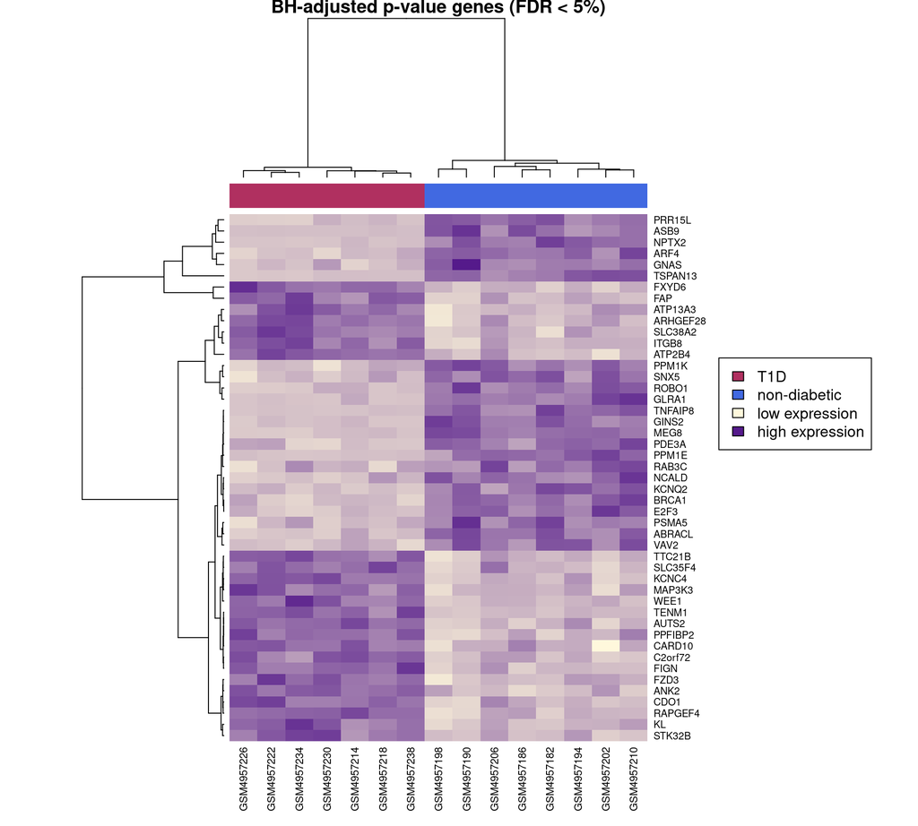

**List of 47 genes represented above:**

```
##  [1] "ABRACL"   "ANK2"     "ARF4"     "ARHGEF28" "ASB9"     "ATP13A3"
##  [7] "ATP2B4"   "AUTS2"    "BRCA1"    "C2orf72"  "CARD10"   "CDO1"
## [13] "E2F3"     "FAP"      "FIGN"     "FXYD6"    "FZD3"     "GINS2"
## [19] "GLRA1"    "GNAS"     "ITGB8"    "KCNC4"    "KCNQ2"    "KL"
## [25] "MAP3K3"   "MEG8"     "NCALD"    "NPTX2"    "PDE3A"    "PPFIBP2"
## [31] "PPM1E"    "PPM1K"    "PRR15L"   "PSMA5"    "RAB3C"    "RAPGEF4"
## [37] "ROBO1"    "SLC35F4"  "SLC38A2"  "SNX5"     "STK32B"   "TENM1"
## [43] "TNFAIP8"  "TSPAN13"  "TTC21B"   "VAV2"     "WEE1"
```

## Repeat random forest

This next list of genes was obtained in a sort of funky way, but I was feeling exploratory! I decided to try using randomForest() in R to train a model using the normalized count matrix and the disease states of the samples. All 15397 genes from the normalized count matrix were fed to the model. The only parameters I changed from the defaults were “nPerm = 50” and “ntree = round(n.genes*2.27)” (34951 trees). I then ranked the genes by their importance to the trained model and looked at the top 100 genes. I noticed that on re-runs, the top 100 most important genes kept changing. I know these models involve randomness and the results depend on the initialization, so this is to be expected to some extent. That said, I felt the similarity in the top 100 genes was disconcertingly low from run to run. I do not know why this occurred, but I figured this was either due to me misusing the model settings, the data set not being suitable for random forest, or both. What I ended up doing was training a random forest 250 times, each time recording the top 500 most important genes for the trained model (~3% of all genes from the count matrix). After doing this, I found the genes that appeared in the top 500 for every single run, assuming that these were less likely to be flukes. This resulted in a list of 300 genes. That list of genes was then clustered again on the heatmap below using the same methods for dist and hclust mentioned earlier. The gene-level dendrogram and the gene names were not shown, as these were illegible for 300 genes:

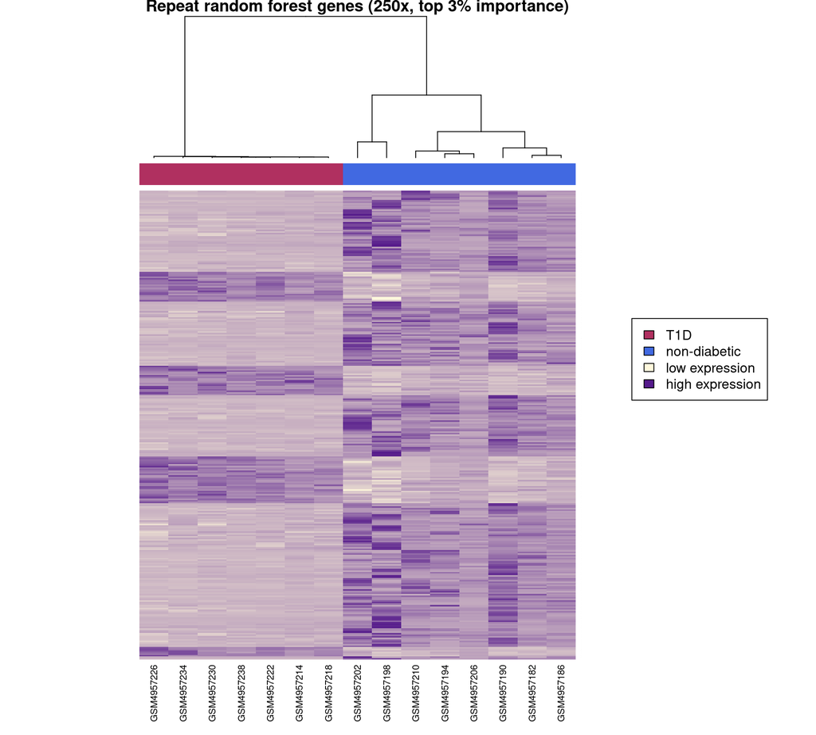

**List of 300 genes represented above:**

```
##   [1] "A1CF"         "ABHD10"       "ABHD15"       "ACPP"         "ACTC1"
##   [6] "ADAMTS5"      "ADAMTSL1"     "ADCYAP1"      "AIG1"         "ANK2"
##  [11] "ANKRD23"      "ANKRD34C"     "ANO5"         "APOBEC2"      "ARF4"
##  [16] "ARG2"         "ARHGAP18"     "ASB9"         "ATG4A"        "ATP2B4"
##  [21] "ATP7B"        "AUTS2"        "AXIN2"        "BAG3"         "BEND6"
##  [26] "BMP5"         "BOC"          "BRCA1"        "BTBD11"       "BZRAP1"
##  [31] "C11orf9"      "C12orf29"     "C15orf59"     "ABRACL"       "C6orf89"
##  [36] "CABLES1"      "CADM1"        "CCDC109B"     "SOGA2"        "CDC26"
##  [41] "CDCP1"        "CDK2AP1"      "CDKN1A"       "CDO1"         "CHST8"
##  [46] "CIAPIN1"      "CMTM6"        "CNPY2"        "CPNE8"        "CSGALNACT1"
##  [51] "CTNNA2"       "CTNNA3"       "CYP2J2"       "CYP2U1"       "CYP4F3"
##  [56] "CYP51A1"      "DACH2"        "DAD1"         "DCTN4"        "DET1"
##  [61] "DGCR10"       "DGKG"         "DHX32"        "DKK4"         "DLK1"
##  [66] "DMD"          "DNAJB9"       "DPAGT1"       "DYNC1I1"      "E2F3"
##  [71] "ECM1"         "EDARADD"      "EEF1A2"       "ELMOD2"       "EML4"
```

[output cut: 45 more lines]

Conducting the repeated fitting of a random forest model may not have been necessary. Also, I may be misusing random forest models. Based on what I have learned so far in this course, fitting a random forest model for any sort of prediction using this data set would probably be over-fitting. That said, because the purpose here was to explore and tease out interesting groups, rather than predict anything, I think the approach I took may have been fine even though I was “winging it” a bit. As can be seen, the genes obtained in this way have pretty uniform expression patterns, at least among the T1D samples. The diabetic samples are clustered very tightly, which was encouraging! Much like the first heatmap shown earlier, a loose checkerboard pattern can be seen, indicating that groups of these genes are changing together in ways that correlate fairly well with disease state.

# **DAVID and EnrichR**

When using both of these tools, I wanted to use some sort of background, so I decided to use the entire set of genes from the normalized count matrix as background. This decision was largely based on a paper from our Week 5 reading material by *Timmons et al.*, which stated that for RNA-seq data an appropriate background could perhaps be the list of genes after zero-count genes are removed [3]. Because zero-count genes have mostly already been removed from the normalized count matrix I am using, the genes represented there seemed to fit this description. I ended up only being able to set a custom background when using DAVID for reasons I will explain later.

## DAVID

I used the DAVID conversion tool to convert the gene symbols from the normalized count matrix to Entrez ID numbers for all gene lists used. For the genetic background list of 15397 gene symbols, DAVID could only convert ~90% (13829 genes) to Entrez IDs, so I just used that list as background instead to generate both annotation lists discussed next. I also changed some of the default annotation sources used by DAVID. The biggest change was including the UCSC transcription factor binding site annotation, but all changes to the defaults are denoted in the screenshot below (green marks):

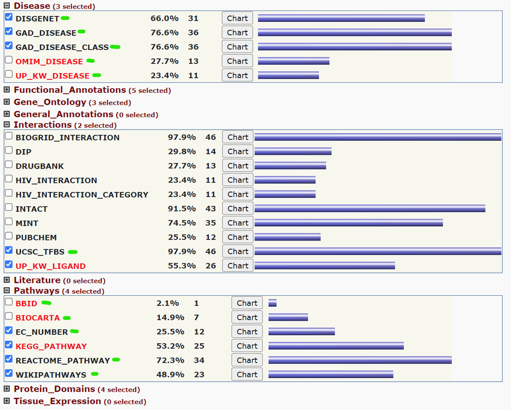

### BH (FDR < 5%) genes

All of the 47 gene symbols from this list converted successfully to Entrez IDs using the DAVID conversion tool. After running DAVID on that list, I downloaded the resulting “Functional Annotation Chart” and filtered terms to include only those that had FDR values (calculated by DAVID) below 10%. This gave me the following list of annotation terms below:

**Table 1**

DAVID annotation for a list of 47 DEGs (T1D to non-diabetic pancreatic iselts), obtained by BH-adjusted t-test p-values (FDR under 5%). Annotation terms are sorted in ascending order by FDR (from DAVID) and were filtered to only include annotation with a DAVID-calculated FDR under 10%.

| Category | Term | Count | Percent | PValue | Fold_Enrichment | Benjamini | FDR |
| --- | --- | --- | --- | --- | --- | --- | --- |
| UCSC_TFBS | S8 | 36 | 76.6 | 2.34e-07 | 1.97 | 4.13e-05 | 1.85e-05 |
| UCSC_TFBS | HNF3B | 33 | 70.2 | 1.89e-06 | 1.99 | 1.66e-04 | 7.45e-05 |
| UCSC_TFBS | CDC5 | 33 | 70.2 | 2.08e-05 | 1.80 | 1.06e-03 | 4.75e-04 |
| UCSC_TFBS | SRY | 32 | 68.1 | 2.41e-05 | 1.84 | 1.06e-03 | 4.75e-04 |
| UCSC_TFBS | POU3F2 | 38 | 80.9 | 3.83e-05 | 1.56 | 1.35e-03 | 6.06e-04 |
| UCSC_TFBS | CART1 | 33 | 70.2 | 5.67e-05 | 1.73 | 1.58e-03 | 7.09e-04 |
| UCSC_TFBS | FOXO1 | 31 | 66.0 | 6.29e-05 | 1.80 | 1.58e-03 | 7.09e-04 |
| UCSC_TFBS | LHX3 | 28 | 59.6 | 1.14e-04 | 1.89 | 2.51e-03 | 1.12e-03 |
| UCSC_TFBS | EN1 | 35 | 74.5 | 1.44e-04 | 1.59 | 2.81e-03 | 1.26e-03 |
| UCSC_TFBS | FOXJ2 | 39 | 83.0 | 2.10e-04 | 1.44 | 3.69e-03 | 1.66e-03 |
| UCSC_TFBS | NKX25 | 38 | 80.9 | 2.93e-04 | 1.45 | 4.68e-03 | 2.10e-03 |
| UCSC_TFBS | FOXD3 | 26 | 55.3 | 3.39e-04 | 1.87 | 4.97e-03 | 2.23e-03 |
| UCSC_TFBS | CHX10 | 29 | 61.7 | 4.06e-04 | 1.72 | 5.50e-03 | 2.47e-03 |
| UCSC_TFBS | TCF11 | 33 | 70.2 | 4.47e-04 | 1.58 | 5.62e-03 | 2.52e-03 |
| UCSC_TFBS | FREAC7 | 32 | 68.1 | 5.00e-04 | 1.60 | 5.82e-03 | 2.61e-03 |
| UCSC_TFBS | NCX | 30 | 63.8 | 6.08e-04 | 1.65 | 5.82e-03 | 2.61e-03 |
| UCSC_TFBS | CEBPA | 23 | 48.9 | 6.25e-04 | 1.96 | 5.82e-03 | 2.61e-03 |
| UCSC_TFBS | SOX9 | 30 | 63.8 | 6.64e-04 | 1.64 | 5.82e-03 | 2.61e-03 |
| UCSC_TFBS | FOXO4 | 34 | 72.3 | 6.72e-04 | 1.52 | 5.82e-03 | 2.61e-03 |
| UCSC_TFBS | AP1 | 36 | 76.6 | 6.89e-04 | 1.46 | 5.82e-03 | 2.61e-03 |
| UCSC_TFBS | POU6F1 | 29 | 61.7 | 7.31e-04 | 1.67 | 5.82e-03 | 2.61e-03 |
| UCSC_TFBS | TBP | 26 | 55.3 | 7.46e-04 | 1.79 | 5.82e-03 | 2.61e-03 |
| UCSC_TFBS | STAT | 26 | 55.3 | 7.60e-04 | 1.79 | 5.82e-03 | 2.61e-03 |
| UCSC_TFBS | RORA2 | 31 | 66.0 | 8.73e-04 | 1.59 | 6.41e-03 | 2.87e-03 |
| UCSC_TFBS | HFH1 | 30 | 63.8 | 9.56e-04 | 1.61 | 6.58e-03 | 2.95e-03 |
| UCSC_TFBS | BACH2 | 29 | 61.7 | 9.72e-04 | 1.65 | 6.58e-03 | 2.95e-03 |
| UCSC_TFBS | HFH3 | 28 | 59.6 | 1.05e-03 | 1.67 | 6.70e-03 | 3.01e-03 |
| UCSC_TFBS | MEIS1BHOXA9 | 32 | 68.1 | 1.10e-03 | 1.54 | 6.70e-03 | 3.01e-03 |
| UCSC_TFBS | NKX61 | 29 | 61.7 | 1.10e-03 | 1.63 | 6.70e-03 | 3.01e-03 |
| UCSC_TFBS | FOXO3 | 22 | 46.8 | 1.23e-03 | 1.92 | 7.23e-03 | 3.25e-03 |

[output cut: 74 more lines]

As seen above, virtually all of the annotation terms that passed the FDR cutoff pertained to UCSC transcription factors. I looked trough the list before filtering by FDR cutoff and most terms that were not from the “UCSC_TFBS” set had very high FDR and adjusted p-values values, with many ~1. The only non-UCSC_TFBS term was from the “UP_KW_LIGAND” annotation set and describes proteins who bind to, or are somehow dependent on, magnesium for their activity [4]. This term also had the highest fold enrichment of 3.22, but was only attached to 9 of the 47 genes and came with accepting an FDR of ~6%. I have learned from the course material to be a bit wary of TF-based annotation because there are many transcription factors that act on many genes, so significant TFs are likely for just about any list of genes. That said, seeing as though the only remotely significant terms are from UCSC_TFBS, I was curious if anything in the literature could back up some of the ones listed above. Interestingly, one very recent study analyzed a microarray experiment on GEO (GSE30122) involving diabetic kidney samples with an aim to better understand diabetic nephropathy and renal failure [5]. They found that 16 transcription factor genes may be implicated in diabetic tubulointerstitial injury [5]. While it is probably important to take what follows with a grain of salt, because *Liu et al.* also used UCSC_TFBS annotation in their analysis [5], I was curious if any of those TF genes they identified were also in my list above. It turns out that most of them (13) were also in Table 1. I have pulled them into their own table below:

**Table 2**

Annotation terms from Table 1 that were found to be associated with diabetic kidney damage by Liu et al. [5]. Terms are ordered by DAVID-calculated FDR in ascending order.

| Category | Term | Count | Percent | PValue | Fold_Enrichment | Benjamini | FDR |
| --- | --- | --- | --- | --- | --- | --- | --- |
| UCSC_TFBS | S8 | 36 | 76.6 | 2.34e-07 | 1.97 | 4.13e-05 | 1.85e-05 |
| UCSC_TFBS | CDC5 | 33 | 70.2 | 2.08e-05 | 1.80 | 1.06e-03 | 4.75e-04 |
| UCSC_TFBS | POU3F2 | 38 | 80.9 | 3.83e-05 | 1.56 | 1.35e-03 | 6.06e-04 |
| UCSC_TFBS | FOXO1 | 31 | 66.0 | 6.29e-05 | 1.80 | 1.58e-03 | 7.09e-04 |
| UCSC_TFBS | FOXJ2 | 39 | 83.0 | 2.10e-04 | 1.44 | 3.69e-03 | 1.66e-03 |
| UCSC_TFBS | SOX9 | 30 | 63.8 | 6.64e-04 | 1.64 | 5.82e-03 | 2.61e-03 |
| UCSC_TFBS | FOXO4 | 34 | 72.3 | 6.72e-04 | 1.52 | 5.82e-03 | 2.61e-03 |
| UCSC_TFBS | AP1 | 36 | 76.6 | 6.89e-04 | 1.46 | 5.82e-03 | 2.61e-03 |
| UCSC_TFBS | HFH1 | 30 | 63.8 | 9.56e-04 | 1.61 | 6.58e-03 | 2.95e-03 |
| UCSC_TFBS | RSRFC4 | 29 | 61.7 | 4.96e-03 | 1.50 | 2.08e-02 | 9.34e-03 |
| UCSC_TFBS | SOX5 | 28 | 59.6 | 1.59e-02 | 1.42 | 5.08e-02 | 2.28e-02 |
| UCSC_TFBS | FAC1 | 28 | 59.6 | 1.71e-02 | 1.41 | 5.18e-02 | 2.33e-02 |
| UCSC_TFBS | BACH1 | 28 | 59.6 | 2.62e-02 | 1.37 | 6.78e-02 | 3.04e-02 |

Many of the terms in the table above are among some of the ones attached to the most genes, and are also associated with accepting a lower FDR. Among them are three members of the FOX family, which are *allegedly* linked to diabetes [6]. That said FOX family genes seem to be involved in many diseases [7,8], so their appearance here may not mean a lot on its own. While I think the overlap between the list of TFs from *Liu et al.* and those in Table 1 likely happened by chance, it is interesting to entertain the idea that this occurred due to some underlying expression pattern or mechanism that happens in both the pancreatic islet and renal tissues of those with diabetes, or at least share similarities in these tissues. All that said, I had a large list of UCSC_TFBS terms in Table 1, so it does not seem unlikely that I could have some of the same terms as those analyzing another data set from another tissue by chance, particularly when ubiquitously important TFs are involved, as I imagine some above are.

**Do your results make sense? Do you have confidence in them? Do you think the annotations missed anything?**

Overall, my results for this list are difficult to make sense of. Almost all terms that were not TF-related had such high test statistics (corrected or uncorrected) that it was pointless to include them. This was not dependent on my choice of background (I checked). The plethora of TFs listed above could probably be researched further via the literature to see if they have relevance to T1D or diabetes in general. I started to do this, and I discussed the findings from one promising paper above, but their work relied on the same annotation set [5]. I imagine many of these TFs would be too non-specific to link definitively to diabetes in a useful way. I have confidence that at least some of the annotation terms for this list of genes do reflect something real, but teasing out what that is seems difficult. I also think the annotation probably missed a lot. Even though this was a small list of genes, I was particularly surprised that there were no terms from any of the other annotation sources selected in DAVID that were even vaguely significant. This lack of significant annotation was surprising to me because the sample and gene clustering on the heatmap for this gene list, shown earlier, looked promising. Also, I know that BH is just one of many ways of estimating the FDR, but it was odd to me that some of the FDR values computed by DAVID were so different than their corresponding BH-adjusted p-value. I maybe should have filtered by BH-adjusted p-value instead, but will continue to use DAVID’s FDR next for consistency.

### Random forest genes

270 of the 300 gene symbols from this list converted to Entrez IDs using DAVID, so I just ran DAVID with that smaller subset. Based on the results from the last gene list, it was clear there were going to be a lot of significant UCSC_TFBS terms, so I divided the annotation into 2 tables to more easily consider the other types of terms. The first table below is for the UCSC_TFBS terms and I will only discuss it briefly:

**Table 3**

UCSC_TFBS terms from the DAVID annotation for 270 genes obtained by repeat random forest modeling (T1D versus non-diabetic pancreatic iselt samples). Annotation terms are sorted in ascending order by FDR (from DAVID) and were filtered to only include annotation with a DAVID FDR under 10%. Genes from the list of TFs associated with diabetic kidney damage by Liu et al. are highlighted in light green [5].

| Category | Term | Count | Percent | PValue | Fold_Enrichment | Benjamini | FDR |
| --- | --- | --- | --- | --- | --- | --- | --- |
| UCSC_TFBS | S8 | 158 | 58.5 | 4.12e-11 | 1.50 | 7.29e-09 | 1.32e-09 |
| UCSC_TFBS | CDC5 | 156 | 57.8 | 2.18e-10 | 1.48 | 1.93e-08 | 3.49e-09 |
| UCSC_TFBS | HNF3B | 144 | 53.3 | 8.96e-10 | 1.51 | 4.57e-08 | 8.27e-09 |
| UCSC_TFBS | CHX10 | 145 | 53.7 | 1.03e-09 | 1.50 | 4.57e-08 | 8.27e-09 |
| UCSC_TFBS | FOXD3 | 125 | 46.3 | 3.90e-09 | 1.57 | 1.38e-07 | 2.50e-08 |
| UCSC_TFBS | RSRFC4 | 156 | 57.8 | 1.91e-08 | 1.41 | 5.64e-07 | 1.02e-07 |
| UCSC_TFBS | AP1 | 185 | 68.5 | 3.28e-08 | 1.31 | 8.30e-07 | 1.50e-07 |
| UCSC_TFBS | HNF1 | 174 | 64.4 | 6.04e-08 | 1.33 | 1.34e-06 | 2.41e-07 |
| UCSC_TFBS | FOXO1 | 141 | 52.2 | 9.56e-08 | 1.43 | 1.88e-06 | 3.40e-07 |
| UCSC_TFBS | LHX3 | 126 | 46.7 | 1.34e-07 | 1.48 | 2.37e-06 | 4.29e-07 |
| UCSC_TFBS | STAT5B | 117 | 43.3 | 1.89e-07 | 1.51 | 3.04e-06 | 5.50e-07 |
| UCSC_TFBS | SOX9 | 146 | 54.1 | 2.20e-07 | 1.39 | 3.24e-06 | 5.86e-07 |
| UCSC_TFBS | FOXO3 | 103 | 38.1 | 3.65e-07 | 1.57 | 4.97e-06 | 8.99e-07 |
| UCSC_TFBS | HFH1 | 147 | 54.4 | 4.36e-07 | 1.38 | 5.52e-06 | 9.97e-07 |
| UCSC_TFBS | FREAC7 | 155 | 57.4 | 4.95e-07 | 1.35 | 5.66e-06 | 1.02e-06 |
| UCSC_TFBS | BACH2 | 141 | 52.2 | 5.12e-07 | 1.39 | 5.66e-06 | 1.02e-06 |
| UCSC_TFBS | EN1 | 166 | 61.5 | 7.48e-07 | 1.31 | 7.79e-06 | 1.41e-06 |
| UCSC_TFBS | MEF2 | 212 | 78.5 | 8.97e-07 | 1.20 | 8.82e-06 | 1.59e-06 |
| UCSC_TFBS | OCT | 147 | 54.4 | 1.47e-06 | 1.35 | 1.37e-05 | 2.48e-06 |
| UCSC_TFBS | FOXJ2 | 192 | 71.1 | 1.89e-06 | 1.24 | 1.68e-05 | 3.03e-06 |
| UCSC_TFBS | HLF | 133 | 49.3 | 3.74e-06 | 1.38 | 3.13e-05 | 5.66e-06 |
| UCSC_TFBS | IRF1 | 92 | 34.1 | 3.89e-06 | 1.55 | 3.13e-05 | 5.66e-06 |
| UCSC_TFBS | NKX61 | 138 | 51.1 | 4.93e-06 | 1.35 | 3.79e-05 | 6.86e-06 |
| UCSC_TFBS | CART1 | 146 | 54.1 | 5.19e-06 | 1.33 | 3.82e-05 | 6.91e-06 |
| UCSC_TFBS | NKX3A | 147 | 54.4 | 6.91e-06 | 1.32 | 4.87e-05 | 8.81e-06 |
| UCSC_TFBS | POU6F1 | 135 | 50.0 | 7.16e-06 | 1.36 | 4.87e-05 | 8.81e-06 |
| UCSC_TFBS | NFE2 | 117 | 43.3 | 8.70e-06 | 1.41 | 5.70e-05 | 1.03e-05 |
| UCSC_TFBS | E4BP4 | 139 | 51.5 | 9.42e-06 | 1.34 | 5.77e-05 | 1.04e-05 |
| UCSC_TFBS | SRY | 135 | 50.0 | 9.45e-06 | 1.35 | 5.77e-05 | 1.04e-05 |
| UCSC_TFBS | HAND1E47 | 143 | 53.0 | 1.17e-05 | 1.32 | 6.88e-05 | 1.24e-05 |

[output cut: 109 more lines]

As seen above, most of the TF genes (14/16) found by *Liu et al.* to potentially be linked to diabetic kidney damage again appear among the lowest FDR and lowest p-value annotation terms (highlighted in green) [5]. This is not particularly surprising because, as mentioned earlier, the first list of 47 genes obtained by inferential statistics is mostly covered by this list of 270 genes from repeat random forest modeling. The test statistics and FDR are all several orders of magnitude lower for 13 of these terms than they were for the same 13 in the annotation of the previous list. I will not discuss the UCSC_TFBS terms further because I already did a bit earlier for the first list. The table for the 29 terms from other sources of annotation for this gene list can be seen below:

**Table 4**

All other DAVID annotation for the 270 genes obtained by repeat random forest modeling. Annotation terms are sorted in ascending order by FDR (from DAVID) and were filtered to only include annotation with a DAVID FDR under 10%. Gene count and raw p-value were omitted from this table for space.

| Category | Term | Percent | Fold_Enrichment | Benjamini | FDR |
| --- | --- | --- | --- | --- | --- |
| GAD_DISEASE_CLASS | METABOLIC | 41.9 | 1.45 | 0.0000054 | 0.0000024 |
| UP_KW_PTM | KW-0165~Cleavage on pair of basic residues | 5.6 | 4.59 | 0.0001030 | 0.0001030 |
| UP_SEQ_FEATURE | TOPO_DOM:Cytoplasmic | 31.9 | 1.68 | 0.0005440 | 0.0005440 |
| UP_KW_BIOLOGICAL_PROCESS | KW-0406~Ion transport | 8.5 | 2.97 | 0.0006050 | 0.0005980 |
| GAD_DISEASE_CLASS | PSYCH | 18.5 | 1.67 | 0.0016875 | 0.0007500 |
| UP_KW_PTM | KW-0325~Glycoprotein | 31.1 | 1.45 | 0.0009530 | 0.0009530 |
| GAD_DISEASE_CLASS | CARDIOVASCULAR | 32.2 | 1.36 | 0.0023727 | 0.0010546 |
| GAD_DISEASE_CLASS | RENAL | 14.4 | 1.74 | 0.0029136 | 0.0012949 |
| GAD_DISEASE_CLASS | CHEMDEPENDENCY | 29.3 | 1.37 | 0.0029136 | 0.0012949 |
| GAD_DISEASE_CLASS | DEVELOPMENTAL | 13.7 | 1.65 | 0.0067513 | 0.0030006 |
| GAD_DISEASE_CLASS | HEMATOLOGICAL | 13.3 | 1.59 | 0.0135791 | 0.0060352 |
| GOTERM_CC_DIRECT | GO:0030424~axon | 6.7 | 3.44 | 0.0065637 | 0.0065054 |
| UP_KW_MOLECULAR_FUNCTION | KW-0407~Ion channel | 5.2 | 3.60 | 0.0079837 | 0.0079837 |
| GAD_DISEASE_CLASS | PHARMACOGENOMIC | 21.9 | 1.35 | 0.0209356 | 0.0093047 |
| UP_KW_CELLULAR_COMPONENT | KW-0628~Postsynaptic cell membrane | 3.3 | 4.81 | 0.0106603 | 0.0100512 |
| UP_KW_CELLULAR_COMPONENT | KW-0256~Endoplasmic reticulum | 13.7 | 1.80 | 0.0106603 | 0.0100512 |
| UP_KW_DOMAIN | KW-0812~Transmembrane | 38.1 | 1.26 | 0.0178878 | 0.0160049 |
| UP_KW_DOMAIN | KW-0732~Signal | 25.9 | 1.37 | 0.0178878 | 0.0160049 |
| UP_KW_DOMAIN | KW-1133~Transmembrane helix | 37.8 | 1.25 | 0.0178878 | 0.0160049 |
| UP_SEQ_FEATURE | TOPO_DOM:Extracellular | 23.3 | 1.68 | 0.0207422 | 0.0207422 |
| UP_KW_CELLULAR_COMPONENT | KW-0472~Membrane | 48.5 | 1.21 | 0.0238219 | 0.0224607 |
| GAD_DISEASE_CLASS | NEUROLOGICAL | 21.1 | 1.29 | 0.0470346 | 0.0235173 |
| GOTERM_CC_DIRECT | GO:0005789~endoplasmic reticulum membrane | 12.6 | 2.02 | 0.0247593 | 0.0245396 |
| GOTERM_CC_DIRECT | GO:0005886~plasma membrane | 35.6 | 1.36 | 0.0434525 | 0.0430668 |
| UP_KW_LIGAND | KW-0915~Sodium | 3.0 | 4.58 | 0.0460162 | 0.0460162 |
| UP_KW_MOLECULAR_FUNCTION | KW-0851~Voltage-gated channel | 3.0 | 4.69 | 0.0473395 | 0.0473395 |
| UP_KW_PTM | KW-1015~Disulfide bond | 21.9 | 1.36 | 0.0585977 | 0.0585977 |
| GAD_DISEASE_CLASS | AGING | 8.1 | 1.49 | 0.1057577 | 0.0608972 |
| GAD_DISEASE_CLASS | NORMALVARIATION | 4.8 | 1.76 | 0.1057577 | 0.0646297 |

Among the annotation terms not from UCSC_TFBS are some that certainly make some sense. A large proportion of the genes (~41%) have “METABOLIC” as the disease class, which is accurate for T1D, if not particularly specific or informative. We also have the GAD_DISEASE_CLASS terms “CARDIOVASCULAR”, “CHEMDEPENDENCY”, “DEVELOPMENTAL”, “HEMATOLOGICAL”, “PHARMACOGENOMIC”, and “NEUROLOGICAL” attached to lower proportions of the genes. While these terms are sufficiently broad to apply to many diseases, and could be here by pure coincidence, when considering the health complications and outcomes associated with diabetes, one could imagine why these terms may appear in a list of T1D-associated genes even if they are not all strictly correct. Supporting that some of these could easily be flukes is the fact that we have the term “PSYCH”, which I am assuming refers to a psychiatric or psychological disorder. More interestingly, we do also have the GAD_DISEASE_CLASS term “RENAL”, which is quite relevant to T1D because diabetes often leads to failure of the kidneys, as discussed earlier. I was curious if the 39 genes that were enriched for this term were among the those enriched for any of the 14 UCSC_TFBS terms associated with diabetic renal damage progression according to *Liu et al.* (highlighted in green in Table 3) [5]. After a quick check using some lines of R code (not shown), it turned out that 95% of the 39 genes with the RENAL term above are among those annotated with the UCSC_TFBS terms that *Liu et al.* said may be linked to diabetic tubulointerstitial injury [5].

**Do your results make sense? Do you have confidence in them? Do you think the annotations missed anything?**

Overall, some of the results for this gene list did make some sense once I thought about them or looked into them further. That said, I have the same apprehension I had for the first list. Other than some of the UCSC_TFBS terms with the lowest test statistics, many of the terms that passed my FDR cutoff of 10% and made it into the tables above had what *Timmons et al.* referred to as “marginal [10e-3 or 10e-4] enrichments” [3]. That said, I am not sure whether they meant 10e-3 or 10e-4 before or after multiple testing corrections. Plenty of the terms that seemed potentially relevant either required bit of a logical stretch, or were broad enough that relating them to diabetes was not a big leap, but not particularly specific or informative either. Only rigorously vetting or investigating the genes enriched for such terms could potentially clarify this ambiguity. I will also say that the DAVID annotation terms for both lists of genes contained plenty of more interesting or obviously relevant terms related to topics like diabetes or kidney failure, but these all came with test statistics and FDRs near or equal to 1. It would be inappropriate to include such terms because I only knew they were likely accurate because of prior knowledge and not because of compelling ORA results. This is one of the reasons my confidence in ORA in general is not very high. I am sure this depends on how many significant and specific annotations there are, but I could probably dig into the details of nearly any annotation list and justify it being relevant somehow. In that case, I would simply confirming what I thought I already knew rather than finding anything truly novel. I also would not be surprised if DAVID missed things for this gene list too, because many of these terms were vague or unhelpful and the expression patterns in the heatmap shown earlier seem like they have promise for holding deeper information on T1D disease states than what was obtained above.

## EnrichR

```
##  [1] "TargetScan_microRNA_2017"
##  [2] "TargetScan_microRNA"
##  [3] "Kinase_Perturbations_from_GEO_down"
##  [4] "Kinase_Perturbations_from_GEO_up"
##  [5] "ENCODE_TF_ChIP-seq_2015"
##  [6] "ENCODE_and_ChEA_Consensus_TFs_from_ChIP-X"
##  [7] "ChEA_2022"
##  [8] "TF-LOF_Expression_from_GEO"
##  [9] "Azimuth_Cell_Types_2021"
## [10] "GTEx_Tissue_Expression_Up"
## [11] "GTEx_Tissue_Expression_Down"
## [12] "Descartes_Cell_Types_and_Tissue_2021"
## [13] "ARCHS4_Tissues"
## [14] "CellMarker_2024"
## [15] "CellMarker_Augmented_2021"
```

[output cut: 55 more lines]

```r
library("enrichR")
library("knitr")
library("kableExtra")


## Read in the two sets of gene symbols used earlier with DAVID and combine with UNION
BH5 <- read.table(file="./Gene_sets/BH_FDR5_genes.txt", sep = "\n")
RF <- read.table(file="./Gene_sets/rf_permut250_genes.txt", sep = "\n")
combined_gene_list <- Reduce(union, c(BH5[[1]], RF[[1]]))


## Get EnrichR DB names and run the ORA

# Much of the code below is from Vignette on the enrichR package:
# https://cran.r-project.org/web/packages/enrichR/vignettes/enrichR.html
websiteLive <- getOption("enrichR.live")
if (websiteLive) {
  listEnrichrSites()
  setEnrichrSite("Enrichr") # Human genes
}
if (websiteLive) dbs <- listEnrichrDbs() # Check out the databases EnrichR can access
selected_dbs <- dbs$libraryName

# Bring my custom list of annotation DBs in from a TXT file
lines <- readLines("./EnrichR/db_list_enrichr")
selected_dbs <- rep(NA, length(lines))
flag = FALSE
for (i in 1:length(lines)) {
  if (!(substr(lines[i], 1, 1) %in% c(">", "#"))) { # symbols used by me to manually filter out DB names
    selected_dbs[i] <- lines[i]
  }
}
selected_dbs <- unique(selected_dbs[!is.na(selected_dbs)])

# Run the enrichment analysis
if (websiteLive) {
  enriched <- enrichr(combined_gene_list, selected_dbs)
}
save(enriched, file="./EnrichR/enriched.sv")
# load(file="./EnrichR/enriched.sv")


## Combine, filter, and sort the annotation results
all_annotation <- do.call("rbind", enriched)
all_annotation <- cbind(rownames(all_annotation), data.frame(all_annotation, row.names=NULL))
names(all_annotation) <- c("Source.DB", names(all_annotation)[2:length(names(all_annotation))])
useful_columns <- c("Source.DB", "Term", "Overlap", "Adjusted.P.value", "Odds.Ratio", "Combined.Score", "Genes")
sig_annotation <- all_annotation[all_annotation$Adjusted.P.value<0.05, useful_columns] # Being a little more stringent with the cutoff
sig_annotation$Odds.Ratio <- round(sig_annotation$Odds.Ratio, digits = 2)
sig_annotation$Combined.Score <- round(sig_annotation$Combined.Score, digits = 2)


## Put the results into a Kable table
annotation_table <- sig_annotation[order(sig_annotation$Adjusted.P.value, decreasing = FALSE),]
annotation_table$Adjusted.P.value <- format(annotation_table$Adjusted.P.value, digits = 3)
names(annotation_table)[names(annotation_table) %in% c("Adjusted.P.value", "Combined.Score")] <- c("Adj.P.val", "Comb.Score")
kable(annotation_table,
      row.names = FALSE,
      caption = "Table of 1324 annotation terms from EnrichR for combined list of 309 genes (BH and random forest). Terms are sorted by EnrichR's adjusted p-value in ascending order (all p-values are below 0.05).", format = "html") %>%
  kable_styling() %>%
  scroll_box(width = "100%", height = "500px") %>%
  row_spec(0, background = "gray90")
```

The table of EnrichR annotation for the combined gene list produced by the code above can be seen below. To cut down on the large number of annotation terms, terms were filtered to include only those with adjusted p-values < 0.05. I was not sure whether to filter by adjusted p-value or combined score, but from the EnrichR paper it looks like their adjusted p-value may be more reliable overall [14]. The gene list and combined score columns are included in the table below for reference and can be seen by scrolling to the right:

**Table 5**

Table of 1324 annotation terms from EnrichR for combined list of 309 genes (BH and random forest). Terms are sorted by EnrichR’s adjusted p-value in ascending order (all p-values are below 0.05).

| Source.DB | Term | Overlap | Adj.P.val | Odds.Ratio | Comb.Score | Genes |
| --- | --- | --- | --- | --- | --- | --- |
| Diabetes_Perturbations_GEO_2022.1 | GSE120299 Alpha-vs-BetaCells Hs Islet Dn | 56/215 | 3.28e-50 | 27.19 | 3269.45 | GLP1R;TFCP2L1;HAPLN4;ADAMTSL1;ADAMTS5;THBD;LRRTM3;SIX2;TIMP2;NEFM;ZNF385D;HADH;TNS1;WLS;KCNH1;CHST8;ENTPD3;UNC5A;EPDR1;TGFBR3;ADCYAP1;CYP2U1;NRG3;KCNQ2;IAPP;TSHZ3;RGS16;ARHGAP18;PTGS2;PPM1E;INS;GLRA1;… |
| CellMarker_2024.1 | Beta Cell Pancreatic Islet Human | 25/108 | 4.38e-20 | 20.80 | 1047.01 | PFKFB2;RGS16;TFCP2L1;INS;LRRTM3;NPTX2;TSPAN1;RNF130;EDARADD;ENTPD3;CADM1;WSCD2;SCD5;PDX1;SORL1;DLK1;BMP5;TGFBR3;ADCYAP1;G6PC2;CYP2U1;GNAS;PIR;IAPP;MRAP2 |
| ARCHS4_Tissues.1 | BETA CELL | 95/2316 | 8.22e-18 | 3.49 | 153.72 | GLP1R;RAB3C;CDKN1A;KCNG3;PCDHGB7;SLC35F4;PTPRM;TFCP2L1;DACH2;HAPLN4;ROBO1;IGF1R;ADAMTSL1;ADAMTS5;THBD;UCHL1;MMP24;ATP7B;LRRTM3;SIX2;ZNF407;TEKT2;TMEM108;NEFM;HADH;TNS1;WLS;KCNH1;CHST8;EDARADD;ARG2;APO… |
| CellMarker_Augmented_2021.1 | Beta cell:Pancreatic Islet | 22/96 | 2.88e-17 | 20.32 | 897.93 | EDARADD;PFKFB2;ENTPD3;CADM1;WSCD2;RGS16;SCD5;MAFA;SORL1;DLK1;INS;BMP5;ADCYAP1;G6PC2;LRRTM3;CYP2U1;GNAS;IAPP;NPTX2;RNF130;TSPAN1;MRAP2 |
| CellMarker_Augmented_2021.2 | Beta cell:Pancreas | 11/23 | 2.57e-12 | 60.53 | 1942.97 | PFKFB2;TGFBR3;SIX2;PDX1;PIR;IAPP;TFCP2L1;NPTX2;DLK1;BMP5;INS |
| Azimuth_Cell_Types_2021.1 | Beta Islet Cell CL0000169 | 8/10 | 9.74e-12 | 261.65 | 7763.57 | ADCYAP1;G6PC2;GSN;IAPP;HADH;NPTX2;DLK1;INS |
| Rare_Diseases_GeneRIF_ARCHS4_Predictions.1 | Permanent neonatal diabetes mellitus | 24/200 | 1.53e-11 | 9.34 | 303.29 | EDARADD;PFKFB2;GLP1R;ENTPD3;SSR4;WSCD2;SLC2A13;PDX1;MAFA;A1CF;ANO5;BMP5;INS;GLRA1;ADCYAP1;G6PC2;STBD1;GNAS;SSR1;IAPP;HADH;NPTX2;MRAP2;SLC38A4 |
| Rare_Diseases_GeneRIF_ARCHS4_Predictions.2 | Glutamate decarboxylase deficiency | 23/200 | 7.10e-11 | 8.87 | 268.21 | PFKFB2;RAB3C;ANKRD34C;ENTPD3;SLC6A17;SSR4;WSCD2;SLC2A13;SCD5;PDX1;SYT16;MAFA;HAPLN4;SGPP2;BMP5;INS;GLRA1;ADCYAP1;G6PC2;ST8SIA5;IAPP;HADH;DYNC1I1 |
| ChEA_2022.1 | SUZ12 20075857 ChIP-Seq MESCs Mouse | 109/3611 | 2.18e-10 | 2.52 | 72.69 | DGKG;CPNE8;KCNG3;IGF1R;SYDE2;SCN9A;TEKT2;FAM53B;STK32B;SCN1B;TNS1;KCNH1;MAP3K5;CSGALNACT1;CARD10;SLC6A17;UNC5A;ADCYAP1;CYP2U1;SCO2;KCNQ2;EEF1A2;TSHZ3;GATA6;TNFRSF11A;ST8SIA5;NPTX2;NTNG2;KL;KCNF1;FZD3;… |
| Rare_Diseases_GeneRIF_ARCHS4_Predictions.3 | Pancreatic beta cell agenesis with neonatal diabetes mellitus | 22/200 | 4.19e-10 | 8.40 | 235.89 | PFKFB2;GLP1R;ENTPD3;CADM1;SSR4;WSCD2;SLC2A13;PDX1;MAFA;ANO5;BMP5;INS;GLRA1;ADCYAP1;G6PC2;GNAS;SSR1;IAPP;HADH;NPTX2;MRAP2;SLC38A4 |
| CellMarker_2024.2 | Beta Cell Pancreas Human | 9/20 | 1.04e-09 | 53.67 | 1382.90 | PFKFB2;TGFBR3;SIX2;PDX1;PIR;TFCP2L1;NPTX2;DLK1;INS |
| Rare_Diseases_GeneRIF_ARCHS4_Predictions.4 | Diabetes mellitus transient neonatal | 21/200 | 2.63e-09 | 7.95 | 206.22 | PFKFB2;ENTPD3;SSR4;WSCD2;SLC2A13;PDX1;IRF2BP2;MAFA;A1CF;ANO5;BMP5;INS;GLRA1;ADCYAP1;G6PC2;MGAT4A;GNAS;IAPP;HADH;NPTX2;SLC38A4 |
| ENCODE_and_ChEA_Consensus_TFs_from_ChIP-X.1 | SUZ12 CHEA | 62/1684 | 9.08e-09 | 2.80 | 64.60 | KCNG3;PCDHGB7;KCNC4;PTPRM;ZCCHC16;HAPLN4;C15ORF59;ADAMTS5;THBD;ATP7B;LRRTM3;SIX2;BOC;NEFM;WLS;MAP3K5;CHST8;EDARADD;VAV3;CSGALNACT1;CARD10;ARG2;SLC6A17;SLC2A13;GAB1;ANO5;TGFBR3;MMP16;NRG3;EEF1A2;TSHZ3;… |
| ChEA_2022.2 | MTF2 20144788 ChIP-Seq MESCs Mouse | 81/2488 | 1.09e-08 | 2.55 | 61.85 | DGKG;DPAGT1;CPNE8;KCNG3;TNFAIP8;PCDHGB7;KCNC4;PTPRM;HAPLN4;IGF1R;ADAMTS5;THBD;ABHD10;MMP24;LRRTM3;STBD1;SIX2;BOC;TIMP2;TMEM108;ITGB8;NEFM;ACAD11;SCN1B;KCNH1;MAP3K5;CHST8;EDARADD;VAV3;CSGALNACT1;CARD10… |
| HDSigDB_Human_2021.1 | Genes Changed In Foxp2/Olfm3-expressing Neurons Of HD Patients Vs Control PMID32681824 | 108/3731 | 1.28e-08 | 2.38 | 61.48 | DGKG;CPNE8;RAB3C;KCNG3;DACH2;GLS;IGF1R;SCN9A;TXNL4A;ZNF445;STK32B;WLS;KCNH1;MAP3K5;CSGALNACT1;EPDR1;ANK2;RAB30;MAP1B;ZCCHC7;NDRG4;MAOB;TSHZ3;MAOA;ARHGEF28;PHYHIPL;ARHGAP18;IQGAP1;ST8SIA5;MYH14;SLC38A2… |
| Rare_Diseases_GeneRIF_ARCHS4_Predictions.5 | Hyperinsulinism diffuse | 20/200 | 1.67e-08 | 7.50 | 179.08 | PFKFB2;ENTPD3;SSR4;MAOA;WSCD2;SLC2A13;PDX1;MAFA;A1CF;ANO5;BMP5;INS;GLRA1;ADCYAP1;G6PC2;STBD1;SSR1;IAPP;HADH;NPTX2 |
| Diabetes_Perturbations_GEO_2022.2 | GSE67543 Fetal-vs-Adult BetaCells Hs Islet Dn | 19/185 | 2.28e-08 | 7.71 | 178.83 | CPNE8;ANKRD34C;RGS16;SYT16;ITPR3;TNFRSF11A;HAPLN4;BMP5;TGFBR3;ADCYAP1;GLRA1;G6PC2;SIX2;SSPN;IAPP;ZNF385D;NPTX2;SNCB;DYNC1I1 |
| ChEA_2022.3 | SUZ12 18974828 ChIP-Seq MESCs Mouse | 58/1564 | 7.99e-08 | 2.79 | 60.96 | CPNE8;KCNG3;PCDHGB7;KCNC4;PTPRM;HAPLN4;ADAMTS5;THBD;ATP7B;LRRTM3;SIX2;BOC;TIMP2;ITGB8;NEFM;MAP3K5;CHST8;EDARADD;VAV3;CARD10;ARG2;SLC6A17;SLC2A13;GAB1;AXIN2;TGFBR3;MMP16;NRG3;KCNQ2;TSHZ3;GATA6;TNFRSF11… |
| ARCHS4_Tissues.2 | PANCREATIC ISLET | 72/2316 | 2.14e-07 | 2.36 | 45.70 | GLP1R;CPNE8;RAB3C;KCNC4;GLS;IGF1R;SYDE2;UCHL1;ITGB8;SEC61B;EDARADD;ENTPD3;SLC6A17;SSR4;SLC2A13;CNPY2;ANO5;PJA2;ADCYAP1;CDCP1;DAD1;MAP1B;CHMP3;IAPP;RAPGEF4;PFKFB2;USP27X;RGS16;PPM1K;NCALD;INS;GLRA1;RAS… |
| ARCHS4_Tissues.3 | CINGULATE GYRUS | 71/2316 | 3.40e-07 | 2.32 | 42.84 | DGKG;TENM1;RAB3C;ECM1;TENM2;KCNG3;PCDHGB7;DACH2;HAPLN4;UCHL1;LRRTM3;TMEM108;NEFM;ZNF385D;WLS;KCNH1;CSGALNACT1;ENTPD3;SLC6A17;UNC5A;SLC2A13;EPDR1;ANK2;ANO5;ADCYAP1;MMP16;NRG3;MAP1B;KCNQ2;EEF1A2;RAPGEF4… |
| ChEA_2022.4 | SUZ12 18692474 ChIP-Seq MESCs Mouse | 55/1531 | 5.88e-07 | 2.67 | 52.28 | DGKG;KCNG3;PCDHGB7;KCNC4;SLC35F4;PTPRM;HAPLN4;ADAMTS5;ATP7B;LRRTM3;SIX2;BOC;MAP3K5;CHST8;EDARADD;VAV3;ARG2;SLC6A17;UNC5A;SLC2A13;GAB1;TGFBR3;MMP16;NRG3;EEF1A2;NDRG4;GATA6;TNFRSF11A;PTGS2;PPM1E;NTN1;GL… |
| Rare_Diseases_GeneRIF_ARCHS4_Predictions.6 | Glucagonoma | 18/200 | 6.33e-07 | 6.63 | 131.97 | PFKFB2;CPNE8;SSR4;SLC2A13;FAM46A;PDX1;MAFA;A1CF;GLS;INS;ADCYAP1;G6PC2;FAP;GNAS;SSR1;IAPP;HADH;SLC38A4 |
| Rare_Diseases_GeneRIF_ARCHS4_Predictions.7 | Metastatic insulinoma | 18/200 | 6.33e-07 | 6.63 | 131.97 | PFKFB2;ENTPD3;SSR4;WSCD2;SLC2A13;PDX1;MAFA;A1CF;ANO5;BMP5;INS;MYO1D;ADCYAP1;G6PC2;GNAS;HADH;NPTX2;SLC38A4 |
| HDSigDB_Human_2021.2 | Top Neuron-Enriched Genes In Humans And Mice PMID29892006 | 43/1000 | 9.27e-07 | 3.16 | 65.03 | DGKG;TENM1;RAB3C;TENM2;NDRG4;SLC35F4;DACH2;PPM1E;NCALD;ROBO1;UCHL1;LRRTM3;SCN9A;ST8SIA5;NEFM;NPTX2;SNCB;STK32B;DYNC1I1;RUNX1T1;KCNH1;BEND6;GABRA2;ENTPD3;SLC6A17;UNC5A;WSCD2;SLC2A13;LGI2;KLHL1;SYT16;BT… |
| HDSigDB_Human_2021.3 | Genes Up-Regulated In Pvalb/Th-expressing Interneurons Of HD Patients Vs Control PMID32681824 | 34/672 | 9.27e-07 | 3.69 | 75.38 | DGKG;TENM1;RAB3C;PHYHIPL;PTPRM;ARHGAP18;IGF1R;LRRTM3;SCN9A;TIMP2;TMEM108;ST8SIA5;ITGB8;DMD;CTNNA2;ZNF385D;GPC6;SLC38A2;VAV3;CSGALNACT1;WWOX;CADM1;INSR;SCD5;GAB1;ANK2;BTBD11;AIG1;TGFBR3;LRFN2;MMP16;NRG… |
| GTEx_Tissue_Expression_Down.1 | GTEX-U3ZG-0001-SM-47JYF blood male 50-59 years | 82/2680 | 1.30e-06 | 2.38 | 51.03 | DGKG;CPNE8;TENM1;RAB3C;ECM1;PTPRM;STON2;HAPLN4;IGF1R;SYDE2;C15ORF59;ADAMTS5;THBD;UCHL1;MMP24;ATP7B;SIX2;SCN9A;BOC;TIMP2;NEFM;ZNF385D;STK32B;SCN1B;TNS1;WLS;CHST8;CSGALNACT1;CARD10;ENTPD3;UNC5A;SLC2A13;… |
| GTEx_Tissue_Expression_Down.2 | GTEX-T5JC-0001-SM-3NMAK blood male 20-29 years | 93/3273 | 1.43e-06 | 2.24 | 46.22 | TENM1;RAB3C;ECM1;TENM2;PCDHGB7;KCNC4;PTPRM;STON2;TFCP2L1;HAPLN4;IGF1R;ADAMTSL1;C15ORF59;ADAMTS5;THBD;UCHL1;MMP24;ATP7B;SIX2;SCN9A;BOC;TIMP2;FAM53B;NEFM;ZNF385D;STK32B;SCN1B;TNS1;WLS;CHST8;VAV3;CSGALNA… |
| HDSigDB_Mouse_2021.1 | Genes Changed In Foxp2/Olfm3-expressing Neurons Of HD Patients Vs Control PMID32681824 | 102/3726 | 1.79e-06 | 2.18 | 45.55 | DGKG;CPNE8;RAB3C;KCNG3;DACH2;GLS;IGF1R;SCN9A;TXNL4A;STK32B;WLS;KCNH1;MAP3K5;CSGALNACT1;EPDR1;ANK2;RAB30;MAP1B;ZCCHC7;NDRG4;MAOB;TSHZ3;MAOA;ARHGEF28;PHYHIPL;ARHGAP18;IQGAP1;ST8SIA5;MYH14;SLC38A2;KL;FZD… |
| HDSigDB_Mouse_2021.2 | Top Neuron-Enriched Genes In Humans And Mice PMID29892006 | 43/1018 | 2.07e-06 | 3.10 | 62.10 | DGKG;TENM1;RAB3C;TENM2;NDRG4;SLC35F4;DACH2;PPM1E;NCALD;ROBO1;UCHL1;LRRTM3;SCN9A;ST8SIA5;NEFM;NPTX2;SNCB;STK32B;DYNC1I1;RUNX1T1;KCNH1;BEND6;GABRA2;ENTPD3;SLC6A17;UNC5A;WSCD2;SLC2A13;LGI2;KLHL1;SYT16;BT… |
| ChEA_2022.5 | AR 19668381 ChIP-Seq PC3 Human | 80/2803 | 3.03e-06 | 2.18 | 38.54 | DGKG;CPNE8;RAB3C;KCNG3;PTPRM;TFCP2L1;DACH2;ROBO1;IGF1R;THBD;ZNF407;BOC;TMEM108;FAM53B;ITGB8;NEFM;ACAD11;HADH;TBC1D22A;STK32B;SCN1B;TNS1;MAP3K5;CHST8;EDARADD;VAV3;SSR4;ELMOD2;SLC2A13;GAB1;ANK2;PJA2;VAV… |

[output cut: 1294 more lines]

While there are still likely plenty of ambiguous and/or coincidental terms in the table above, at face value EnrichR seems to have provided a more on-point and deeper set of annotation. This is not too surprising, because more sources (and more up-to-date sources) of annotation could be selected than with DAVID. Most of the terms among those with the 10 lowest adjusted p-values in Table 5 are obviously relevant and either directly reference diabetes, pancreatic Beta cells, or both. Interestingly, there is also the term “Glutamate decarboxylase deficiency”, and glutamate decarboxylase is likely important and relevant to the process of developing diabetes [15,16]. The list above is long, so I will summarize a few terms and trends to highlight how this list seems a little bit more interesting than the ones produced by DAVID. I used to grep() in R to tally unique terms containing several broad queries of interest to get a feel for the annotation in the table above:

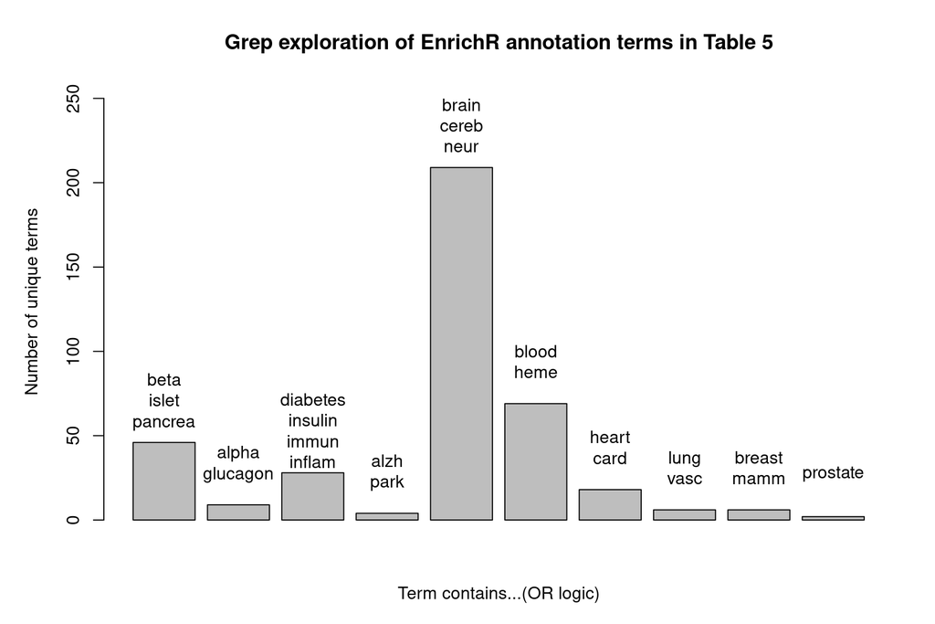

```r
## Find and count some terms of interest in the annotation terms, plot them
grep_query <- function(string) {
  return(length(unique(grep(string, sig_annotation$Term, ignore.case=TRUE, value=TRUE))))
}
queries <- c("beta|islet|pancrea", "alpha|glucagon", "diabetes|insulin|immun|inflam", "alzh|park", "brain|cereb|neur", "blood|heme", "heart|card", "lung|vasc", "breast|mamm", "prostate")
category_counts <- rep(NA, length(queries))
category_counts <- as.numeric(lapply(queries, grep_query))
names(category_counts) <- lapply(queries, function(x) gsub("\\|","\n", x))
par(mar=c(5, 5, 4, 2),  mgp=c(3, 1, 0))
bplot <- barplot(category_counts, main="Grep exploration of EnrichR annotation terms in Table 5", ylab="Number of unique terms", xlab="Term contains...(OR logic)", ylim = c(0,max(category_counts)+50), axisnames = FALSE)
text(x = bplot, y = category_counts + 25, labels = names(category_counts))
```

As seen above, plenty of terms have to do with beta cells, pancreatic endrocrine tissue, insulin, diabetes, and related concepts. As expected, plenty of the genes enriched for terms containing those queries included *INS*, and some of those gene lists were small, but plenty were large, and a handful did not even contain *INS*. It is probably worth mentioning at this point that one of the strongest clusters during Part One of this assignment during hierarchical and k-means clustering was consistently a small group of the same 4 genes containing *INS* and *GCG*. I chose not to pursue that cluster because it seemed biologically accurate yet trivial. Interestingly, there was a relatively large number of terms pertaining to brain tissue compared to other broad tissue types. This may have been a fluke based on my choice of annotation databases, or some other confounding factor in the samples, but it is interesting because diabetes does have associations with increased risk for certain neurodegenerative diseases [17]. On that note there, were a small handful of terms directly pertaining to either Alzheimer’s or Parkinsons disease above. It is also worth noting that the only GO terms that passed my adjusted p-value threshold where neurological in nature even though they were a bit broad: Neuron Projection (GO:0043005) and Axon (GO:0030424) (GO_Cellular_Component, p-adj ≈ 0.0085 for both). Two honorable mentions are the terms “Serum Chromium Levels” (p-adj ≈ 0.044) and “Blood Urea Nitrogen” (p-adj ≈ 0.027). I found “Serum Chromium Levels” interesting because I remembered that chromium plays a role in glucose homeostasis and the levels of chromium are often dimished in those with diabetes, at least for T2D [18]. “Blood Urea Nitrogen” was also interesting because I remember reading in the early weeks of this course that this is a promising metabolomic biomarker for diabetes risk and outcomes [19-22], so it was interesting to see 9 genes were enriched for this term. There were also a total of 256 TargetScan_microRNA terms in Table 5. Certain microRNAs have been associated with T1D and/or T2D in the literature [23-26], so I figured it would be interesting to see if any of these appeared in Table 5:

```r
## Searching for some microRNAs in my annotations identified/discussed in relevant literature [23-26]:
literature1 <- c("miR-200", "miR-7", "miR-184", "miR-212", "miR-132", "miR-130a", "miR-130b", "miR-152") # 1) https://doi.org/10.2337/dbi19-0016
literature2 <- c("miR-30a-5p", "miR-30d-5p", "miR-30c-5p") # 2) https://doi.org/10.1186/s12933-019-0918-x
literature3 <- c("hsa-miR-1-3p") # 3) https://doi.org/10.1038/s41598-023-35836-8
literature4 <- readLines("./EnrichR/mirs_uniq") # 4) https://doi.org/10.3389/fendo.2018.00180 : The Review had many, so had to use grep/sort/uniq on the paper text
combined <- unique(c(literature1, literature2, literature3, literature4))
miRNA_enrichr <- sig_annotation[grep("TargetScan_microRNA_", sig_annotation$Source.DB), "Term"]
literature_miRNAs_found <- grep(paste(combined, collapse="|"), miRNA_enrichr, ignore.case = TRUE, value = TRUE)
paste(round(100*length(literature_miRNAs_found)/length(combined)), "% of ", length(combined), " diabetes-associated miRNAs pulled from literature [23-26] were found in Table 5:", sep="")
literature_miRNAs_found
```

```
## [1] "33% of 42 diabetes-associated miRNAs pulled from literature [23-26] were found in Table 5:"
##  [1] "mmu-miR-704"    "mmu-miR-718"    "hsa-miR-28-3p"  "mmu-miR-707"
##  [5] "mmu-miR-744"    "hsa-miR-770-5p" "mmu-miR-130b"   "mmu-miR-721"
##  [9] "mmu-miR-130a"   "mmu-miR-362-5p" "hsa-miR-103b"   "hsa-miR-196a"
## [13] "hsa-miR-1263"   "mmu-miR-877"
```

As can be seen, some of the microRNAs discussed in a few papers as being potentially important to diabetes did appear as terms in my EnrichR annotation table. To me, these miRNAs and the associated genes from my list could be interesting and exciting leads to research further. That said, this may also may be a little bit like the UCSC_TFBS terms discussed before, in that I had a large list of microRNA terms to start out with and a smaller list of those identified as important in the literature, so perhaps some were bound to overlap. Still, I bet there could potentially be something biologically interesting to tease out of that set of 256 microRNAs in Table 5 (or the genes enriched for them) with a more involved analysis.

**Do your results make sense? Do you have confidence in them? Do you think the annotations missed anything?**

Overall, I had more confidence in the list produced by EnrichR, partly because it is a newer tool and partly because it seemed to allow for a deeper set of annotation. As discussed above, many more obviously accurate or relevant terms, e.g. beta cell, insulin, pancreas, diabetes, etc., appeared as significant after filtering by adjusted p-value than in the DAVID results. This was encouraging even though these terms themselves did not reveal any particularly novel information (although the genes enriched for them might). It is worth mentioning again that EnrichR was using the default background (if any) due to limitations in the R package, which may have skewed the test statistics and content of the filtered results in Table 5. Much like for DAVID, I am sure the ORA done with EnrichR missed things because it will always be limited by the annotation that exists about the genes in question, which reflects our improving but limited understanding of molecular biology, the human genome, and diseases (even well-studied ones). As mentioned in the paper by *Timmons et al.*, analyses involving functional enrichment are also influenced by a variety of sources of bias that can be mitigated, but never completely removed or accounted for [3]. Also, I still feel like it would be very easy to solely pursue and confirm what I already knew about or expected to see in a list of ORA terms. This makes ORA and related analyses limited without more rigorous accompanying analyses and/or input from those who have a more advanced foundation in molecular biology. There were plenty of odd or difficult to interpret terms among the ~1300 in Table 5 that I did not give any thought to, even though they technically passed the significance threshold and some even had a low adjusted p-value.

# **GSEA**

I really wanted to do GSEA in R for this assignment, but I found the GSEABase documentation to be a little bit confusing and sparse on the specifics of actually using the package to run GSEA. I found a popular alternative package for running GSEA called “fgsea”, as well as some helpful guides on how to use it [27-29]. My understanding is that the algorithm behind the scenes of fgsea is similar in principle to the original one from the Broad Institute, but it runs a lot faster and is allegedly capable of accounting for the FDR more accurately [30,31]. The code I wrote to use this package to conduct GSEA can be seen below, and some of the code and approaches taken were modified from examples online [27-29,32]. I conducted GSEA on the expression data from the T1D vs non-diabetic pancreatic islet samples I have been using so far [1]. I used the MSigDB GMT file containing all human pathways for this analysis, which I downloaded from the GSEA website [33].

When looking at the pathway files downloaded from the GSEA website, I realized that I could use pathways with all genes labeled with Entrez IDs or with gene symbols. Using the Entrez IDs seemed like there would be less room for error/ambiguity in the GSEA, but I tested both approaches. I ended up using Entrez IDs, even though 1508 out of the 15397 gene symbols from the normalized count matrix did not map to any Entrez IDs (much like with DAVID). I did this because using Entrez IDs led to slightly more significant pathways under the same significance threshold (123 versus 92 pathways at p-adjusted < 0.1). Also, the table of significant pathways obtained using Entrez IDs included all of the same pathway names as the smaller set obtained by using gene symbols (code/results not shown). It is also worth noting that I had to calculate a ranking statistic on my own to use with fgsea, and after looking around a bit I ended up using “-log<sub>10</sub>(p-value)*log<sub>2</sub>(mean-fold-change)” as per a post the Bioconductor.org support forum [32,34,35]. This approach seemed more robust to me, as it takes the magnitude and direction of fold change into account, in addition to the magnitude of the p-value [32]. Fold change was calculated as “mean(T1D)/mean(non-diabetic)” for each gene, and the p-value was from the Welch’s t-test comparing the same sample groups. I did not adjust the p-values in any way. Also, there were still some genes (72) with mostly zero values for all samples from one or both disease status groups, so I had to filter these out because they resulted in infinite or undefined values.

```r
library("fgsea")
library("org.Hs.eg.db")
library("knitr")
library("kableExtra")


## Import the and prepare the normalized count matrix from Granlund et al. (CPM, TMM, log via edgeR) [1,2]:
# Import the SRA Run table CSV, downloaded from: https://www.ncbi.nlm.nih.gov/Traces/study/?acc=PRJNA682616&o=acc_s%3Aa
SraRunTable <- read.csv("./GEO_files/SraRunTable.csv") # This is my guide to the samples' source/identities
# Get normalized counts, originally from: https://www.ncbi.nlm.nih.gov/geo/query/acc.cgi?acc=GSE162689
normalized_counts <- read.csv("./GEO_files/GSE162689_TMM_LG_220817.csv", row.names = 1, header = TRUE)
colnames(normalized_counts) <- SraRunTable$GEO_Accession..exp.
# Prepare the disease state sample groups and filter counts matrix to only include endocrine samples
t1d <- list() # diabetic
t1d$all <- SraRunTable$GEO_Accession..exp.[SraRunTable$disease_state == "type 1 diabetic"]
t1d$endocrine <- SraRunTable$GEO_Accession..exp.[SraRunTable$disease_state == "type 1 diabetic" & SraRunTable$source_name == "human pancreatic islet tissue"]
t1d$exocrine <- SraRunTable$GEO_Accession..exp.[SraRunTable$disease_state == "type 1 diabetic" & SraRunTable$source_name == "human pancreatic exocrine tissue"]
ndb <- list() # non-diabetic
ndb$all <- SraRunTable$GEO_Accession..exp.[SraRunTable$disease_state == "non-diabetic"]
ndb$endocrine <- SraRunTable$GEO_Accession..exp.[SraRunTable$disease_state == "non-diabetic" & SraRunTable$source_name == "human pancreatic islet tissue"]
ndb$exocrine <- SraRunTable$GEO_Accession..exp.[SraRunTable$disease_state == "non-diabetic" & SraRunTable$source_name == "human pancreatic exocrine tissue"]
normalized_counts <- normalized_counts[, c(ndb$endocrine, t1d$endocrine )]


## Convert symbols to Entrez IDs, the following link was helpful for this:
# https://www.biostars.org/p/255657/
gene.symbols <- rownames(normalized_counts)
reference <- org.Hs.eg.db
ids <- select(reference, keys = gene.symbols, columns = c("ENTREZID", "SYMBOL"), keytype = "SYMBOL")
# Remove incorrect Entrez IDs for ambiguous symbols HBD, MEMO1, and TEC (manually looked them up and chose one)
ids <- ids[!(ids$ENTREZID %in% c("100187828", "7795", "100124696")),]
# n_occur <- data.frame(table(ids$SYMBOL))
# n_occur[n_occur$Freq > 1,]
# sum(is.na(ids$ENTREZID)) # 1508 missing Entrez ids/genes omited
normalized_counts <- normalized_counts[ids$SYMBOL[!is.na(ids$ENTREZID)],]
rownames(normalized_counts) <- ids$ENTREZID[!is.na(ids$ENTREZID)]


## Prepare a suitable ranking statistic, I settled on the method described in 1) below after reading about all options:
# 1) https://support.bioconductor.org/p/85681/
# 2) https://www.biostars.org/p/467197/
# 3) https://www.biostars.org/p/298312/
# 4) https://www.biostars.org/p/347273/
p.values <- rep(NA, dim(normalized_counts)[1])
log2.fold.change <- rep(NA, dim(normalized_counts)[1])
for (i.gene in 1:dim(normalized_counts)[1]) {
  control <- as.numeric(normalized_counts[i.gene, ndb$endocrine])
  disease <- as.numeric(normalized_counts[i.gene, t1d$endocrine])
  p.values[i.gene] <- t.test(control, disease)$p.value
  log2.fold.change[i.gene] <- log2(mean(disease)/mean(control))
}
# hist(p.values) # useful to check!
ranking_stats <- -log10(p.values)*log2.fold.change # This takes test statistic, FC magnitude, and FC direction into account
names(ranking_stats) <- rownames(normalized_counts)
save(ranking_stats, file="./GSEA/ranking_stats_Entrez.sv")
# load(file="./GSEA/ranking_stats_Entrez.sv")
# plot(rank(-ranking_stats), ranking_stats) # useful to check!


## The following helpful resources on using the fgsea package informed my code below this line:
# https://stephenturner.github.io/deseq-to-fgsea/
# https://www.biostars.org/p/467197/
# https://bioinformatics-core-shared-training.github.io/cruk-summer-school-2018/RNASeq2018/html/06_Gene_set_testing.nb.html


## Load the file with all the MSigDB pathways, downloaded from Broad GSEA software site: https://www.gsea-msigdb.org/gsea/downloads.jsp
msigdb.pathways.all <- gmtPathways("./GSEA/msigdb_v2023.2.Hs_GMTs/msigdb.v2023.2.Hs.entrez.gmt")
# Run fgsea to conduct the actual GSEA analysis
GSEA_results <- fgsea(pathways = msigdb.pathways.all,
                      stats = ranking_stats[is.finite(ranking_stats)], # 72 cases of -Inf or Nan due to largely 0's in normalized count data
                      eps = 0) # want numerical accuracy for low p-values
save(GSEA_results, file="./GSEA/GSEA_results_Entrez.sv")
# load(file="./GSEA/GSEA_results_Entrez.sv")


## Filter and sort pathways by adjusted p-value (FDR < 10%) and prepare for table
sig.pathways <- as.data.frame(GSEA_results[GSEA_results$padj<0.1,])
# Calculate overlap (i.e. leading edge genes / pathway genes), similar to what EnrichR reports
le_lengths <- as.numeric(lapply(sig.pathways$leadingEdge, length))
for (i in 1:length(sig.pathways$size)) {
  sig.pathways[i, "size"] <- paste(le_lengths[i], "/", sig.pathways[i, "size"], sep="")
}
names(sig.pathways)[names(sig.pathways) == "size"] <- "Overlap"
# Convert leading edge genes from Entrez IDs back to symbols for readability
ids <- ids[!is.na(ids$ENTREZID),]
sig.pathways$leadingEdge <- as.character(lapply(sig.pathways$leadingEdge, function(x) paste(as.character(lapply(x, function(y) ids[ids$ENTREZID==y,"SYMBOL"])), collapse=",")))


## Reformat the data and put it all in a Kable table
annotation_table_fgsea <- sig.pathways[order(sig.pathways$padj, decreasing = FALSE),]
annotation_table_fgsea$padj <- format(annotation_table_fgsea$padj, digits = 3)
annotation_table_fgsea$NES <- round(annotation_table_fgsea$NES, digits = 2)
annotation_table_fgsea <- annotation_table_fgsea[,!(names(annotation_table_fgsea) %in% c("pval", "ES", "log2err"))]
annotation_table_fgsea$pathway <- as.character(lapply(annotation_table_fgsea$pathway, function(x) paste(strsplit(x, "(?<=.{50})", perl = TRUE)[[1]], collapse = "\n"))) # https://stackoverflow.com/questions/11619616/how-to-split-a-string-into-substrings-of-a-given-length
kable(annotation_table_fgsea,
      row.names = FALSE,
      caption = "123 signficant GSEA pathways (adjusted p-values under 0.1), based on the expression ranking statistic: -log~10~(p-value)*log~2~(mean-fold-change). Pathways are sorted in ascending order by adjusted p-values.", format = "html") %>%
  kable_styling() %>%
  scroll_box(width = "100%", height = "500px") %>%
  row_spec(0, background = "gray90")
```

The code above used pre-ranked GSEA (via fgsea) to produce the following table of significant pathways (p-adjusted < 0.1) involving genes from the normalized count matrix (ranking metric described earlier). All leading edge genes can be seen for each pathway by scrolling right in the table. It is also worth noting that I omitted some columns to save space and added the “Overlap” column (inspired by EnrichR), which shows the number of genes in the leading edge followed by the size of the pathway:

**Table 6**

123 signficant GSEA pathways (adjusted p-values under 0.1), based on the expression ranking statistic: -log<sub>10</sub>(p-value)*log<sub>2</sub>(mean-fold-change). Pathways are sorted in ascending order by adjusted p-values.

| pathway | padj | NES | Overlap | leadingEdge |
| --- | --- | --- | --- | --- |
| MURARO_PANCREAS_BETA_CELL | 3.49e-31 | -2.13 | 213/855 | INS,MAFA,NPTX2,PPM1E,IAPP,TNFRSF11A,DLK1,TSPAN13,RGS16,ABRACL,ADCYAP1,NEFM,WSCD2,PFKFB2,KCNG3,RASD1,LRRTM3,SCN1B,IGSF11,SIX2,CAPN13,TFCP2L1,LOC154761,ENTPD3,TGFBR3,MEG3,THBD,TSPAN1,PRUNE2,HOPX,ROBO1,E… |
| VANGURP_PANCREATIC_BETA_CELL | 1.69e-16 | -2.40 | 52/104 | INS,MAFA,NPTX2,IAPP,DLK1,TSPAN13,RGS16,ADCYAP1,WSCD2,PFKFB2,LOC154761,ENTPD3,TGFBR3,TSPAN1,PRUNE2,G6PC2,HADH,CDKN1A,SAMD11,GNAS,GSN,PDX1,CYP2U1,PCSK1,SCD5,C1QL1,UCHL1,TIMP2,TMEM150C,CADM1,DNAJB9,TNS1,… |
| MURARO_PANCREAS_ALPHA_CELL | 1.23e-05 | 1.68 | 114/495 | CSGALNACT1,FAP,GLS,SLC7A14,GPC6,SH3RF1,ABHD15,TMEM236,SLC38A4,DPP4,ALDH1A1,WDR59,KCTD12,FXYD6,A1CF,GCG,IRX2,SCN3B,TM4SF4,CPNE8,PCSK2,PGR,SPOCK3,RGS17,OCRL,SLC22A17,ARRDC4,MAMLD1,KIF12,ASPH,PDK3,QDPR,I… |
| BENPORATH_ES_WITH_H3K27ME3 | 3.74e-04 | -1.62 | 116/650 | PPM1E,DLK1,GABRA2,ADCYAP1,LRFN2,NEFM,KLHL1,P2RX5,RXRG,OLIG3,SIX2,NTN1,VAV3,LOC154761,ENTPD3,CYP2J2,THBD,FOXE1,CHST8,SPAG6,PRUNE2,ESR1,SLCO5A1,ST8SIA5,NTNG2,DGKG,HHAT,SAMD11,DACH2,COMP,GRIN2D,KCNF1,PIR… |
| GSE19888_ADENOSINE_A3R_INH_PRETREAT_AND_ACT_BY_A3R _VS_A3R_INH_AND_TCELL_MEMBRANES_ACT_MAST_CELL_UP | 4.82e-04 | 1.91 | 43/164 | IRF2BP2,DIP2B,EIF4B,CXCR4,PIK3CA,MED13L,ZNF217,SAT1,ATXN7L1,BTG1,ATM,CBX7,JMY,RNPC3,UBN2,FBXL20,TMEM43,SH3KBP1,MKRN1,HBP1,ZFP36,MBTD1,CANX,NSD1,BCL6,BACH1,TCF7L2,MARCKS,ZEB2,ATRX,RAB11FIP2,DUSP1,EPHA4… |
| TCTATGA_MIR376A_MIR376B | 1.76e-03 | 1.99 | 17/65 | SLITRK6,ANK2,GPC6,GRIK5,EIF4B,CEBPB,CAPN3,NRP1,NFKBIZ,PTMA,MACROD2,PLEKHA5,GRIK2,NDST1,PLAG1,CELF4,INSIG2 |
| MIR12136 | 2.93e-03 | 1.43 | 158/837 | TENM1,FRMD4B,BACH2,SCN9A,IRF2BP2,NUP205,FZD3,PHIP,TNRC6B,TMEM236,KCTD12,ZNF362,CXCR4,GAB1,PIK3CA,CPNE8,MED13L,BCL11A,USH2A,NCL,CEBPB,SLC38A2,LUZP2,ZCCHC8,FBXO32,KLF9,PRRG4,MYLIP,SECISBP2L,IL6ST,SH3GLB… |
| VANGURP_PANCREATIC_ALPHA_CELL | 2.93e-03 | 2.07 | 19/37 | FAP,GLS,DPP4,ALDH1A1,KCTD12,GCG,IRX2,TM4SF4,PCSK2,PLCE1,GC,PLIN3,HIGD1A,F10,ITGB1,PEMT,CLU,TMEM176A,PAPPA2 |
| DESCARTES_MAIN_FETAL_ISLET_ENDOCRINE_CELLS | 3.09e-03 | -2.00 | 15/49 | INS,MAFA,ASB9,IAPP,G6PC2,HADH,SSTR5-AS1,GNAS,PCSK1,CABP7,ABCC8,PTPRN,STX1A,CNIH2,CASR |
| GOBP_NERVOUS_SYSTEM_PROCESS | 6.33e-03 | -1.46 | 206/956 | INS,NPTX2,GLRA1,IAPP,GABRA2,RGS16,SCN1B,PTGS2,P2RX5,TMEM108,IGSF11,P2RX6,CTNNA2,TSHZ3,COMP,GRIN2D,GNAS,GLP1R,ARF4,OR2B11,ATP2B2,TAS2R60,C1QL1,UCHL1,KCNA2,GRIN2A,TSPEAR,TMEM150C,TTC8,GLRA3,NTRK1,MAPT,O… |
| GOBP_RNA_PROCESSING | 1.37e-02 | 1.35 | 226/904 | PRPF3,A1CF,NAT10,FUS,RBM42,NCL,SLC38A2,DDX52,CRNKL1,SF1,LIN28A,INTS3,ZCCHC8,SART1,RBM5,CDK11A,RBM23,EXOSC10,URM1,SMAD1,BICD1,SNORA64,PQBP1,RPRD2,TSEN34,YBX1,CCNL2,HNRNPA3,SNORA55,METTL14,SCARNA17,RNPC… |
| GOBP_SENSORY_PERCEPTION_OF_SMELL | 1.37e-02 | -1.68 | 99/318 | OR2B11,TTC8,OR10J1,OR2A12,OR11H6,OR2A5,OR4D1,OR4N5,OR4S1,BBS4,OR6C76,OR4X2,OR8I2,OR1S1,OR10X1,OR1J4,OR52M1,OR4F6,OR2F2,OR10A7,OR1N2,OR8D2,OR8B3,OR1C1,OR5H2,OR4D9,OR13H1,OR13J1,OR6C4,OR5M9,OR5P2,OR7A17… |
| GOMF_OLFACTORY_RECEPTOR_ACTIVITY | 1.37e-02 | -1.68 | 92/305 | OR2B11,OR10J1,OR2A12,OR11H6,OR2A5,OR4D1,OR4N5,OR4S1,OR6C76,OR4X2,OR8I2,OR1S1,OR10X1,OR1J4,OR52M1,OR4F6,OR2F2,OR10A7,OR1N2,OR8D2,OR8B3,OR1C1,OR5H2,OR4D9,OR13H1,OR13J1,OR6C4,OR5M9,OR5P2,OR7A17,OR4C15,OR… |
| MIR186_5P | 1.37e-02 | 1.46 | 80/479 | FRMD4B,DMD,SCN9A,RUNX1T1,GPC6,SH3RF1,FZD3,PHIP,LMO4,TNRC6B,ARHGEF38,ABL2,ARAP2,IRX2,BCOR,PIK3CA,ZC3H12B,ASPH,PDK3,LUZP2,MACC1,SUMO4,NRP1,NOL4,SP4,ACSS3,GNAI1,LRCH2,PPP1CC,KLF7,TMEM168,LRRC66,PAK2,RIMS… |
| FAN_EMBRYONIC_CTX_BIG_GROUPS_CAJAL_RETZIUS | 1.64e-02 | -1.63 | 74/371 | TNFRSF11A,ADCYAP1,NEFM,PRPH,ENTPD3,GAP43,EPDR1,RCAN2,NDUFA8,CDKN1A,OLFM1,RASSF6,GPR6,SNCB,PCSK1,CABP7,CCDC88C,TP73,LSAMP,NTRK1,STK32C,MYH14,ME1,MAP1A,NDRG4,SV2B,FRMPD1,MRAP2,TXN,SLC17A6,EPHA8,ATP6V1A,… |
| GOMF_DNA_BINDING_TRANSCRIPTION_REPRESSOR_ACTIVITY | 1.64e-02 | 1.64 | 57/247 | BACH2,ZNF587B,IRX2,BCL11A,CEBPB,ZNF217,OVOL1,MYC,IRX1,ZNF558,ZNF131,ZNF337,ZNF19,ZEB1,ZNF418,ETV6,MNT,TBX18,FOXD3,LRRFIP1,LEF1,PROX1,FOXK2,MXD1,ZNF778,NFE2L3,BCL6,ZNF398,ZBTB37,BACH1,ZNF559,FOXK1,NR1D… |
| GOMF_TRANSCRIPTION_REGULATOR_ACTIVITY | 1.64e-02 | 1.26 | 318/1413 | BACH2,RUNX1T1,ZNF587B,IRF2BP2,ZNF275,CREG1,LMO4,BCL9,GATA6,ZNF362,POU6F2,IRX2,ZNF787,BCOR,KLF15,ZNF701,BCL3,MED13L,BCL11A,PGR,ZNF709,FUS,CEBPB,ZNF217,OVOL1,WWOX,ZNF468,GRHL2,TFCP2,SF1,MYC,POU5F2,ZNF44… |
| GSE13738_RESTING_VS_BYSTANDER_ACTIVATED_CD4_TCELL_ UP | 1.64e-02 | 1.78 | 44/136 | TENM1,TNRC6B,BCL9,USP27X,TGFBR2,MED13L,CHML,SERINC5,STK17A,IL6ST,ATM,PECAM1,RPRD2,ZNF564,STAG2,SLC40A1,UBN2,IGF1R,PLAG1,PSIP1,CHMP3,THRB,CGN,ZNF711,SCAF11,PRKAA2,FAM117B,ATF7IP,ZNF550,GIMAP7,GPRASP2,T… |
| LAKE_ADULT_KIDNEY_C17_COLLECTING_SYSTEM_PCS_STRESS ED_DISSOC_SUBSET | 1.64e-02 | 1.66 | 47/214 | CSGALNACT1,GLS,BACH2,SH3RF1,PCDH9,GAB1,MED13L,MACC1,SAT1,BMPR1B,IL6ST,ITGA2,MAP3K14,ZNF292,RAPGEF2,SLC38A1,NEAT1,NFKBIZ,ELF3,PRKAG2,MACROD2,FNIP2,SHROOM3,LRRFIP1,FHOD3,TJP1,MYO10,BTG2,ZFP36,XIST,ERBB4… |
| GSE29614_CTRL_VS_DAY7_TIV_FLU_VACCINE_PBMC_DN | 1.71e-02 | -1.80 | 45/133 | INS,CD38,BHLHE41,ATG4A,GUSBP11,SEC61B,SLC39A14,GNG7,OSTC,PARM1,RPN2,CCDC113,EAF2,SRPRB,SSR3,STT3A,ARHGAP42,MYO1D,PRDX4,DNAJB11,USO1,SPATS2,SPAG5,C11orf24,ZWINT,TYMS,CRELD2,HSP90B1,PPIB,FKBP14,SEC11C,R… |
| GSE2706_UNSTIM_VS_2H_LPS_AND_R848_DC_UP | 1.77e-02 | 1.77 | 58/151 | PRLHR,ZNF275,PPFIBP2,ZNF787,TSPYL6,LUZP2,NKTR,CNTN3,ZNF250,ID3,CDK9,MTMR3,ZNF227,NBPF1,MSANTD2,ZNF689,ZNF500,NSD1,ZNF398,TMEM150A,KLHL24,ZKSCAN4,HHEX,HNRNPU,WRAP73,ZCCHC3,TAS2R40,CDAN1,ZNF766,PAAF1,RS… |
| MIR381_3P | 2.12e-02 | 1.47 | 71/371 | AUTS2,FRMD4B,GPC6,DCC,FZD3,PHIP,RNF144A,ARAP2,LRRC4,KDM6A,PCSK2,SPOCK3,FUS,NKTR,MET,NHS,KLF3,ARHGAP12,ZNF558,LANCL2,POPDC3,AKAP12,ELOVL7,ACVR2B,PRPF8,USP1,HEATR5B,PPP3CA,LEF1,PTP4A1,ASXL1,PSIP1,SRSF12… |
| DESCARTES_FETAL_INTESTINE_ENS_NEURONS | 2.58e-02 | -1.86 | 21/81 | ADCYAP1,NEFM,PRPH,ENTPD3,GAP43,CTNNA2,OLFM1,EEF1A2,ATP2B2,UCHL1,TMEM151B,MAPT,TUBB2A,TUBB2B,NDRG4,SGIP1,MAP1B,NRSN1,VAT1L,DNER,CNTN5 |
| GOCC_NUCLEAR_OUTER_MEMBRANE_ENDOPLASMIC_RETICULUM_ MEMBRANE_NETWORK | 2.58e-02 | -1.43 | 215/921 | PTGS2,SFTPA1,CYP2J2,TM6SF2,G6PC2,HHAT,GRIN2D,PLA2G4A,LPIN3,NAT8L,CYP2U1,DAD1,SCD5,SRD5A1,CHODL,UCHL1,KCNA2,SLC27A2,PIGA,RASGRF2,GRIN2A,PIGP,WLS,DNAJB9,TMEM132A,PITPNM1,FICD,SLC33A1,SGPP2,NDRG4,SEC61A1… |
| KEGG_OLFACTORY_TRANSDUCTION | 2.58e-02 | -1.66 | 93/307 | OR2B11,OR10J1,OR2A12,OR11H6,OR2A5,PRKX,OR4D1,OR4N5,OR4S1,OR6C76,OR4X2,OR8I2,OR1S1,OR10X1,OR1J4,OR52M1,OR4F6,OR2F2,OR10A7,OR1N2,OR8D2,OR1C1,OR5H2,OR4D9,OR13H1,OR13J1,OR6C4,OR5M9,GNAL,OR5P2,OR7A17,OR4C1… |
| MARTENS_TRETINOIN_RESPONSE_UP | 2.58e-02 | -1.56 | 67/436 | INS,UNC5A,NEFM,SCN1B,DKK4,PLCH2,CD22,CHST8,SLC6A17,CHAC1,KLHDC8A,OLFM1,EEF1A2,LPIN3,OR2B11,GPR6,TRIM29,SNCB,CABP7,GEM,C1QL1,VAV2,CDKN1C,F2RL3,KNDC1,KRTAP16-1,SERPINA1,PCSK9,EPHA8,HTR3A,CD1C,GZMH,HSPB7… |
| REACTOME_OLFACTORY_SIGNALING_PATHWAY | 2.58e-02 | -1.66 | 92/308 | OR2B11,OR10J1,OR2A12,OR11H6,OR2A5,OR4D1,OR4N5,OR4S1,OR6C76,OR4X2,OR8I2,OR1S1,OR10X1,OR1J4,OR52M1,OR4F6,OR2F2,OR10A7,OR1N2,OR8D2,OR8B3,OR1C1,OR5H2,OR4D9,OR13H1,OR13J1,OR6C4,OR5M9,GNAL,OR5P2,OR7A17,OR4C… |
| GAVISH_3CA_METAPROGRAM_EPITHELIAL_NEUROENDOCRINE | 2.59e-02 | -1.92 | 16/44 | INS,ASB9,IAPP,RASD1,MEG3,HADH,GNAS,UCHL1,PFN2,MAP1B,MIR7-3HG,GAD2,PAM,PTPRN,SCGB2A1,CPE |
| NCOA4_TARGET_GENES | 2.59e-02 | 1.34 | 140/785 | WEE1,RUNX1T1,ATP2B4,DET1,ODF2L,GAB1,ZNF787,KLF15,MED13L,CPPED1,RPL8,PISD,VEGFC,RNASEH2A,SF1,CNTN3,RAF1,TP53INP1,TTC38,ATXN7L1,MAN1A1,MYLIP,CDKL3,SAE1,ATP13A3,ZNF131,PHLPP2,OTUB1,BICD1,STAT1,SECISBP2,P… |
| GOBP_RNA_SPLICING | 2.85e-02 | 1.46 | 93/402 | PRPF3,FUS,RBM42,NCL,SLC38A2,CRNKL1,SF1,ZCCHC8,SART1,RBM5,RBM23,PQBP1,TSEN34,YBX1,CCNL2,HNRNPA3,METTL14,RNPC3,SNRNP35,FAM98B,ZNF326,PRPF8,HNRNPH1,PSIP1,SRSF12,CIRBP,SNRNP27,CELF4,RBM15,AFF2,TSEN2,USP49… |

[output cut: 93 more lines]

Looking at Table 6, it is clear that plenty of the significant pathways make sense. The top 2 lowest adjusted p-value results pertain to beta cells and the pancreas, with a decent proportion of the pathway genes represented in the leading edge in both cases. The 3rd lowest adjusted p-value also pertains to the pancreas, but involves alpha cells instead of beta cells. Including those pathways just mentioned, there are 10 unique pathways containing the grep queries “beta”, “pancrea”, “islet”, “alpha”, or “endocr”. More interestingly, there are a lot more pathways associated with terms that offer a little more granularity concerning the molecular biology. For example, unlike the results from the ORA analyses conducted previously, there are 31 pathways associated with GO terms in the table above. Among these are some that make sense immediately like the following GO terms:

- GOCC_NUCLEAR_OUTER_MEMBRANE_ENDOPLASMIC_RETICULUM_MEMBRANE_NETWORK
- GOCC_TRANSPORT_VESICLE
- GOCC_SECRETORY_VESICLE

These are all cellular components and locations that are quite relevant to endocrine tissue function. Other terms of relevance are:

- GOBP_FATTY_ACID_HOMEOSTASIS
- GOBP_POSITIVE_REGULATION_OF_BROWN_FAT_CELL_DIFFERENTIATION

These are relevant because fat and carbohydrate metabolism are interconnected, and imbalances in fatty acid metabolism and fat management are likely connected somehow to the imbalances in glucose metabolism that occur in cases of diabetes [36-38]. That said, the leading edges for both of those pathways mainly just include *INS* and/or one other gene, which makes sense, but would not provide leads for further research. The pathway labeled “GOBP_AMINE_CATABOLIC_PROCESS” is interesting to me because, while this term may be somewhat non-specific, amino acid catabolism occurs upstream of the urea cycle in the liver, which is important for nitrogen management/disposal in the body [39]. Amino acid catabolism is also important for using the energy stored in brown adipose tissue, or even branched-chain amino acids, to generate heat for the body [39]. As just discussed above, brown adipose tissue is relevant to mechanisms involved in diabetes (whether causal or not), and so are branched-chain amino acids [39]. Branched-chain amino acids are a promising circulating metabolomic biomarker of diabetes [40]. As mentioned earlier, elevated urea in the blood is also a potential biomarker for diabetes [19-22]. These samples are not from liver tissue, and the 4/15 genes in that pathway, in addition to the term “Blood Urea Nitrogen” from earlier, may have been a coincidence, but it would be interesting to explore the genes enriched for all of these pathways and terms further. Like before, there were some pathways pertaining specifically to neurons or their function than I would not have expected, but I will not go into them here. The set of pathways I found the *most* surprising and interesting was the following:

- GOMF_OLFACTORY_RECEPTOR_ACTIVITY
- KEGG_OLFACTORY_TRANSDUCTION
- REACTOME_OLFACTORY_SIGNALING_PATHWAY
- DURANTE_ADULT_OLFACTORY_NEUROEPITHELIUM_OLFACTORY_ENSHEATHING_GLIA
- GOBP_SENSORY_PERCEPTION_OF_SMELL
- GOMF_MOLECULAR_TRANSDUCER_ACTIVITY
- GOMF_RETINOIC_ACID_RESPONSIVE_ELEMENT_BINDING

I was pretty confused when I saw these pathways at first, but upon further research it turns out that these terms are quite relevant to diabetes! There is apparently a fairly well-established link between diabetes and a diminished sense of smell, although the specific nature of this link is still being explored [41-44]. Also it seems that retinoic acid does likely play a role in the differentiation and/or regeneration of cells involved in olfactory processes [45,46].

I was excited to see that there are 23 pathways in Table 6 pertaining to various microRNAs. That said, a series of grep queries revealed that none of the miRNA genes for which these pathways were named overlapped with those discussed earlier as being associated with diabetes in some literature I had found [23-26].

Some of my discussion above is quite speculative in nature and to some extent ignores differences between tissues/cells, and how this might discredit the connections I am drawing about certain pathways of interest. That said, thinking and speculating like I did above highlights how enrichment-based analyses, coupled with appropriate literature research, could be a great tool to generate leads for validation or elimination with more rigorous followup work. I still think confirmation bias is definitely a possibility, but GSEA seems like a powerful tool for exploration and gaining insight. Some of the pathways in Table 6 certainly seem to relate, at least broadly, with some of the details I have been learning about diabetes over the past few weeks from the literature.

# **References**

[1] https://www.ncbi.nlm.nih.gov/geo/query/acc.cgi?acc=GSE162689

[2] Seiron, P., Stenwall, A., Hedin, A., Granlund, L., Esguerra, J. L. S., Volkov, P., Renström, E., Korsgren, O., Lundberg, M., & Skog, O. (2021). Transcriptional analysis of islets of Langerhans from organ donors of different ages. In M. G. von Herrath (Ed.), PLOS ONE (Vol. 16, Issue 3, p. e0247888). Public Library of Science (PLoS). https://doi.org/10.1371/journal.pone.0247888

[3] Timmons, J. A., Szkop, K. J., & Gallagher, I. J. (2015). Multiple sources of bias confound functional enrichment analysis of global -omics data. In Genome Biology (Vol. 16, Issue 1). Springer Science and Business Media LLC. https://doi.org/10.1186/s13059-015-0761-7

[4] https://www.uniprot.org/keywords/KW-0460

[5] Liu, J., Duan, G., Yang, W., Zhang, S., Liu, F., Peng, Y., Sun, L., Liu, Y., & Xiao, L. (2023). Identification of transcription factors related to diabetic tubulointerstitial injury. In Journal of Translational Medicine (Vol. 21, Issue 1). Springer Science and Business Media LLC. https://doi.org/10.1186/s12967-023-04069-8

[6] Katoh, M., & Katoh, M. (2004). Human FOX gene family (Review). In International Journal of Oncology. Spandidos Publications. https://doi.org/10.3892/ijo.25.5.1495

[7] QIANG, Y., WANG, F., YAN, S., ZHANG, H., ZHU, L., CHEN, Z., TU, F., WANG, D., WANG, G., WANG, W., & CHEN, Z. (2015). Abnormal expression of Forkhead Box J2 (FOXJ2) suppresses migration and invasion in extrahepatic cholangiocarcinoma and is associated with prognosis. In International Journal of Oncology (Vol. 46, Issue 6, pp. 2449–2458). Spandidos Publications. https://doi.org/10.3892/ijo.2015.2957

[8] Benayoun, B. A., Caburet, S., & Veitia, R. A. (2011). Forkhead transcription factors: key players in health and disease. In Trends in Genetics (Vol. 27, Issue 6, pp. 224–232). Elsevier BV. https://doi.org/10.1016/j.tig.2011.03.003

[9] https://www.uniprot.org/keywords/KW-0165

[10] Konda, P. Y., Marella, S., Natava, R., & Chippada, A. (2020). Diabetes affects hepatic and renal glycoproteins: effect of Boswellia ovalifoliolata on glycoproteins proportions in diabetes induced hepatic and renal injury. In Journal of Diabetes & Metabolic Disorders (Vol. 19, Issue 1, pp. 153–162). Springer Science and Business Media LLC. https://doi.org/10.1007/s40200-020-00487-3

[11] https://www.uniprot.org/keywords/KW-0325

[12] https://www.uniprot.org/keywords/KW-0971

[13] https://cran.r-project.org/web/packages/enrichR/vignettes/enrichR.html

[14] Chen, E. Y., Tan, C. M., Kou, Y., Duan, Q., Wang, Z., Meirelles, G. V., Clark, N. R., & Ma’ayan, A. (2013). Enrichr: interactive and collaborative HTML5 gene list enrichment analysis tool. In BMC Bioinformatics (Vol. 14, Issue 1). Springer Science and Business Media LLC. https://doi.org/10.1186/1471-2105-14-128

[15] Jun, H. S., Khil, L. Y., & Yoon, J. W. (2002). Role of glutamic acid decarboxylase in the pathogenesis of type 1 diabetes. In Cellular and Molecular Life Sciences CMLS (Vol. 59, Issue 11, pp. 1892–1901). Springer Science and Business Media LLC. https://doi.org/10.1007/pl00012512

[16] Wada, E., Onoue, T., Kinoshita, T., Hayase, A., Handa, T., Ito, M., Furukawa, M., Okuji, T., Kobayashi, T., Iwama, S., Sugiyama, M., Takagi, H., Hagiwara, D., Suga, H., Banno, R., Goto, M., & Arima, H. (2021). Adult-onset autoimmune diabetes identified by glutamic acid decarboxylase autoantibodies: a retrospective cohort study. In Diabetologia (Vol. 64, Issue 10, pp. 2183–2192). Springer Science and Business Media LLC. https://doi.org/10.1007/s00125-021-05516-1

[17] Santiago, J. A., Karthikeyan, M., Lackey, M., Villavicencio, D., & Potashkin, J. A. (2023). Diabetes: a tipping point in neurodegenerative diseases. In Trends in Molecular Medicine (Vol. 29, Issue 12, pp. 1029–1044). Elsevier BV. https://doi.org/10.1016/j.molmed.2023.09.005

[18] Zhao, F., Pan, D., Wang, N., Xia, H., Zhang, H., Wang, S., & Sun, G. (2021). Effect of Chromium Supplementation on Blood Glucose and Lipid Levels in Patients with Type 2 Diabetes Mellitus: a Systematic Review and Meta-analysis. In Biological Trace Element Research (Vol. 200, Issue 2, pp. 516–525). Springer Science and Business Media LLC. https://doi.org/10.1007/s12011-021-02693-3

[19] Du, J., Zhang, W., Niu, J., & Wang, S. (2024). Association between blood urea nitrogen levels and the risk of diabetes mellitus in Chinese adults: secondary analysis based on a multicenter, retrospective cohort study. In Frontiers in Endocrinology (Vol. 15). Frontiers Media SA. https://doi.org/10.3389/fendo.2024.1282015

[20] Zhong, J.-B., Yao, Y.-F., Zeng, G.-Q., Zhang, Y., Ye, B.-K., Dou, X.-Y., & Cai, L. (2023). A closer association between blood urea nitrogen and the probability of diabetic retinopathy in patients with shorter type 2 diabetes duration. In Scientific Reports (Vol. 13, Issue 1). Springer Science and Business Media LLC. https://doi.org/10.1038/s41598-023-35653-z

[21] Liu, S., Qiu, C., Li, W., Li, X., Liu, F., & Hu, G. (2024). Blood urea nitrogen to serum albumin ratio as a new prognostic indicator in type 2 diabetes mellitus patients with chronic kidney disease. In Scientific Reports (Vol. 14, Issue 1). Springer Science and Business Media LLC. https://doi.org/10.1038/s41598-024-58678-4

[22] Xie, Y., Bowe, B., Li, T., Xian, H., Yan, Y., & Al-Aly, Z. (2018). Higher blood urea nitrogen is associated with increased risk of incident diabetes mellitus. In Kidney International (Vol. 93, Issue 3, pp. 741–752). Elsevier BV. https://doi.org/10.1016/j.kint.2017.08.033

[23] Eliasson, L., & Esguerra, J. L. S. (2020). MicroRNA Networks in Pancreatic Islet Cells: Normal Function and Type 2 Diabetes. In Diabetes (Vol. 69, Issue 5, pp. 804–812). American Diabetes Association. https://doi.org/10.2337/dbi19-0016

[24] Pordzik, J., Jakubik, D., Jarosz-Popek, J., Wicik, Z., Eyileten, C., De Rosa, S., Indolfi, C., Siller-Matula, J. M., Czajka, P., & Postula, M. (2019). Significance of circulating microRNAs in diabetes mellitus type 2 and platelet reactivity: bioinformatic analysis and review. In Cardiovascular Diabetology (Vol. 18, Issue 1). Springer Science and Business Media LLC. https://doi.org/10.1186/s12933-019-0918-x

[25] Morales-Sánchez, P., Lambert, C., Ares-Blanco, J., Suárez-Gutiérrez, L., Villa-Fernández, E., Garcia, A. V., García-Villarino, M., Tejedor, J. R., Fraga, M. F., Torre, E. M., Pujante, P., & Delgado, E. (2023). Circulating miRNA expression in long-standing type 1 diabetes mellitus. In Scientific Reports (Vol. 13, Issue 1). Springer Science and Business Media LLC. https://doi.org/10.1038/s41598-023-35836-8

[26] Vaishya, S., Sarwade, R. D., & Seshadri, V. (2018). MicroRNA, Proteins, and Metabolites as Novel Biomarkers for Prediabetes, Diabetes, and Related Complications. In Frontiers in Endocrinology (Vol. 9). Frontiers Media SA. https://doi.org/10.3389/fendo.2018.00180

[27] https://www.biostars.org/p/467197/

[28] https://stephenturner.github.io/deseq-to-fgsea/

[29] https://bioinformatics-core-shared-training.github.io/cruk-summer-school-2018/RNASeq2018/html/06_Gene_set_testing.nb.html

[30] https://bioinformatics.stackexchange.com/questions/149/are-fgsea-and-broad-institute-gsea-equivalent

[31] Korotkevich, G., Sukhov, V., Budin, N., Shpak, B., Artyomov, M. N., & Sergushichev, A. (2016). Fast gene set enrichment analysis. Cold Spring Harbor Laboratory. https://doi.org/10.1101/060012

[32] https://support.bioconductor.org/p/85681/

[33] https://www.gsea-msigdb.org/gsea/downloads.jsp

[34] https://www.biostars.org/p/298312/

[35] https://www.biostars.org/p/347273/

[36] Bano, G. (2013). Glucose homeostasis, obesity and diabetes. In Best Practice & Research Clinical Obstetrics & Gynaecology (Vol. 27, Issue 5, pp. 715–726). Elsevier BV. https://doi.org/10.1016/j.bpobgyn.2013.02.007

[37] Maliszewska, K., & Kretowski, A. (2021). Brown Adipose Tissue and Its Role in Insulin and Glucose Homeostasis. In International Journal of Molecular Sciences (Vol. 22, Issue 4, p. 1530). MDPI AG. https://doi.org/10.3390/ijms22041530

[38] Acosta-Montaño, P., & García-González, V. (2018). Effects of Dietary Fatty Acids in Pancreatic Beta Cell Metabolism, Implications in Homeostasis. In Nutrients (Vol. 10, Issue 4, p. 393). MDPI AG. https://doi.org/10.3390/nu10040393

[39] Torres, N., Tobón-Cornejo, S., Velazquez-Villegas, L. A., Noriega, L. G., Alemán-Escondrillas, G., & Tovar, A. R. (2023). Amino Acid Catabolism: An Overlooked Area of Metabolism. In Nutrients (Vol. 15, Issue 15, p. 3378). MDPI AG. https://doi.org/10.3390/nu15153378

[40] Ramzan, I., Ardavani, A., Vanweert, F., Mellett, A., Atherton, P. J., & Idris, I. (2022). The Association between Circulating Branched Chain Amino Acids and the Temporal Risk of Developing Type 2 Diabetes Mellitus: A Systematic Review & Meta-Analysis. In Nutrients (Vol. 14, Issue 20, p. 4411). MDPI AG. https://doi.org/10.3390/nu14204411

[41] Sienkiewicz-Oleszkiewicz, B., & Hummel, T. (2024). Olfactory function in diabetes mellitus. In Journal of Clinical & Translational Endocrinology (Vol. 36, p. 100342). Elsevier BV. https://doi.org/10.1016/j.jcte.2024.100342

[42] Lietzau, G., Davidsson, W., Östenson, C.-G., Chiazza, F., Nathanson, D., Pintana, H., Skogsberg, J., Klein, T., Nyström, T., Darsalia, V., & Patrone, C. (2018). Type 2 diabetes impairs odour detection, olfactory memory and olfactory neuroplasticity; effects partly reversed by the DPP-4 inhibitor Linagliptin. In Acta Neuropathologica Communications (Vol. 6, Issue 1). Springer Science and Business Media LLC. https://doi.org/10.1186/s40478-018-0517-1

[43] Faour, M., Magnan, C., Gurden, H., & Martin, C. (2022). Olfaction in the context of obesity and diabetes: Insights from animal models to humans. In Neuropharmacology (Vol. 206, p. 108923). Elsevier BV. https://doi.org/10.1016/j.neuropharm.2021.108923

[44] Gouveri, E., & Papanas, N. (2021). Olfactory Dysfunction: A Complication of Diabetes or a Factor That Complicates Glucose Metabolism? A Narrative Review. In Journal of Clinical Medicine (Vol. 10, Issue 23, p. 5637). MDPI AG. https://doi.org/10.3390/jcm10235637

[45] Paschaki, M., Cammas, L., Muta, Y., Matsuoka, Y., Mak, S.-S., Rataj-Baniowska, M., Fraulob, V., Dolle, P., & Ladher, R. K. (2013). Retinoic acid regulates olfactory progenitor cell fate and differentiation. In Neural Development (Vol. 8, Issue 1). Springer Science and Business Media LLC. https://doi.org/10.1186/1749-8104-8-13

[46] Rawson, N. E., & LaMantia, A. ‐S. (2006). Once and again: Retinoic acid signaling in the developing and regenerating olfactory pathway. In Journal of Neurobiology (Vol. 66, Issue 7, pp. 653–676). Wiley. https://doi.org/10.1002/neu.20236

[47] Das, S., McClain, C. J., & Rai, S. N. (2020). Fifteen Years of Gene Set Analysis for High-Throughput Genomic Data: A Review of Statistical Approaches and Future Challenges. In Entropy (Vol. 22, Issue 4, p. 427). MDPI AG. https://doi.org/10.3390/e22040427

[48] Zyla, J., Marczyk, M., Weiner, J., & Polanska, J. (2017). Ranking metrics in gene set enrichment analysis: do they matter? In BMC Bioinformatics (Vol. 18, Issue 1). Springer Science and Business Media LLC. https://doi.org/10.1186/s12859-017-1674-0

[49] Qureshi, R., & Sacan, A. (2013). Weighted set enrichment of gene expression data. In BMC Systems Biology (Vol. 7, Issue Suppl 4, p. S10). Springer Science and Business Media LLC. https://doi.org/10.1186/1752-0509-7-s4-s10

[50] https://en.wikipedia.org/wiki/Sensitivity_and_specificity

[51] Geistlinger, L., Csaba, G., Santarelli, M., Ramos, M., Schiffer, L., Turaga, N., Law, C., Davis, S., Carey, V., Morgan, M., Zimmer, R., & Waldron, L. (2020). Toward a gold standard for benchmarking gene set enrichment analysis. In Briefings in Bioinformatics (Vol. 22, Issue 1, pp. 545–556). Oxford University Press (OUP). https://doi.org/10.1093/bib/bbz158

[52] Subramanian, A., Tamayo, P., Mootha, V. K., Mukherjee, S., Ebert, B. L., Gillette, M. A., Paulovich, A., Pomeroy, S. L., Golub, T. R., Lander, E. S., & Mesirov, J. P. (2005). Gene set enrichment analysis: A knowledge-based approach for interpreting genome-wide expression profiles. In Proceedings of the National Academy of Sciences (Vol. 102, Issue 43, pp. 15545–15550). Proceedings of the National Academy of Sciences. https://doi.org/10.1073/pnas.0506580102

[53] Maleki, F., Ovens, K., Hogan, D. J., & Kusalik, A. J. (2020). Gene Set Analysis: Challenges, Opportunities, and Future Research. In Frontiers in Genetics (Vol. 11). Frontiers Media SA. https://doi.org/10.3389/fgene.2020.00654